# Prueba estadística y Estimación

La prueba y la estimación consisten en verificar estadísticamente una hipótesis sobre un parámetro de la población objetivo.

- Explicación de la verificación de hipótesis, la estimación y los errores de tipo I y tipo II.
- Procedimiento y cálculo para la verificación y estimación de la media y varianza poblacional en una y dos poblaciones.
- Explicación de datos pareados y no pareados.
- Procedimiento y cálculo para la verificación de la proporción y el número de no conformidades en una y dos poblaciones.
- Procedimiento y cálculo para la prueba de tablas de contingencia.

[Audio_1](https://drive.google.com/file/d/1ooN4RGI_ER0i1gH8DR2dePOacDXYZpGt/view?usp=drive_link)

```python
import os

try:
  os.chdir('../Python/QCKentei2')
except:
  pass

path = os.getcwd()
```

```python
import numpy as np
import matplotlib.pyplot as plt
import pandas as pd

import gspread
from google.oauth2.service_account import Credentials
```

## 04-01 Prueba estadística

検定

### 1. Prueba estadística

検定とは

La **prueba estadística** consiste en verificar estadísticamente una **hipótesis**（仮説） sobre una población objetivo, como por ejemplo: ¿Se puede considerar que la media poblacional es 50.0? o ¿Ha disminuido la varianza poblacional?. Para ello, se toma una muestra de la población y, a partir de los datos obtenidos, se realiza la verificación mediante métodos estadísticos.

En una prueba de hipótesis, la **hipótesis alternativa (H1)**（対立仮説） representa lo que se desea investigar sobre la población objetivo, y la **hipótesis nula (H0)**（帰無仮説） es la hipótesis que niega la hipótesis alternativa.

- Prueba unilateral（片側検定）
- Prueba bilateral（両側検定）

El error de juzgar que la hipótesis alternativa es verdadera cuando la hipótesis nula es en realidad verdadera se denomina **error de Tipo I** o **error del precipitado**（慌て者の誤り）, y su probabilidad se conoce com **nivel de significancia**（有意水準）, representado por el símbolo **$ \alpha $**.

Por otro lado, el error de juzgar que la hipótesis nula es verdadera cuando la hipótesis alternativa es en realidad verdadera se denomina **error de Tipo II** o **error del distraído**（ぼんやり者の誤り）, y su probabilidad se representa con el símbolo **$ \beta $**.

En general, existe una relación entre $ \alpha $ y $ \beta $: cuando se aumenta $ \alpha $, $ \beta $ tiende a disminuir, y cuando se reduce $ \alpha $, $ \beta $ suele aumentar. En una prueba estadística, es importante poder detectar correctamente cuando la hipótesis alternativa es verdadera, y la probabilidad de lograrlo se denomina **poder estadístico $ (1-\beta) $**（検出力）.

Si el estadístico de prueba cae dentro de la región de rechazo, en lugar de pensar que ha ocurrido algo raro, se juzga que la hipótesis inicial era incorrecta y se rechaza la hipótesis nula.

La **región de rechazo**（棄却域） es el conjunto de valores del estadístico de prueba en el cual se decide rechazar la hipótesis nula.

[Audio_2](https://drive.google.com/file/d/1lm7A3Imig5lkMqGgMNC1iaRumggK2x35/view?usp=drive_link)

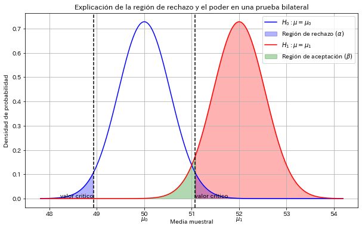

```python
from scipy.stats import norm
import japanize_matplotlib

# Media poblacional y desviación estándar
mu0 = 50        # H0: μ = μ0
mu1 = 52        # H1: μ = μ1
sigma = 3       # Desviación estándar
n = 30          # Tamaño de la muestra
alpha = 0.05    # Nivel de significancia

# Error estándar de la media muestral
se = sigma / np.sqrt(n)

# Prueba de dos colas → α/2
z_alpha = norm.ppf(1 - alpha / 2)  # Valor crítico（z）
x_crit_right = mu0 + z_alpha * se
x_crit_left = mu0 - z_alpha * se

# x
x = np.linspace(mu0 - 4*se, mu1 + 4*se, 1000)

# Distribución bajo H0 y H1
y0 = norm.pdf(x, mu0, se)
y1 = norm.pdf(x, mu1, se)

plt.figure(figsize=(10, 6))

# Distribución bajo H0
plt.plot(x, y0, label=r'$H_0: \mu = \mu_0$', color='blue')
plt.fill_between(x, y0, where=(x <= x_crit_left) | (x >= x_crit_right), color='blue', alpha=0.3, label=r'Región de rechazo $(\alpha)$')

# Distribución bajo H1
plt.plot(x, y1, label=r'$H_1: \mu = \mu_1$', color='red')
plt.fill_between(x, y1, where=(x >= x_crit_right), color='red', alpha=0.3)
plt.fill_between(x, y1, where=(x <= x_crit_left), color='red', alpha=0.3)
plt.fill_between(x, y1, where=(x > x_crit_left) & (x < x_crit_right), color='green', alpha=0.3, label=r'Región de aceptación $(\beta)$')

plt.axvline(x_crit_left, color='black', linestyle='--')
plt.axvline(x_crit_right, color='black', linestyle='--')
plt.text(mu0, -0.09, r'$ μ_0 $', ha='center')
plt.text(mu1, -0.09, r'$ μ_1 $', ha='center')
plt.text(x_crit_left, 0, 'valor critico', ha='right', va='bottom')
plt.text(x_crit_right, 0, 'valor critico', ha='left', va='bottom')

plt.title('Explicación de la región de rechazo y el poder en una prueba bilateral')
plt.xlabel('Media muestral')
plt.ylabel('Densidad de probabilidad')
plt.legend(loc='upper right')
plt.grid(True)
plt.show()
```

### 2. Pasos de la prueba de hipótesis

検定の手順

Paso 1: Establecimiento de la hipótesis nula H0 y la hipótesis alternativa H1. 帰無仮説と対立仮説の設定

Paso 2: Establecimiento del nivel de significación 有意水準の設定

Paso 3: Establecimiento de la estadística de prueba 検定統計量の選定

Paso 4: Establecimiento de la región de rechazo 棄却域の設定

Paso 5: Selección de la muestra y los datos サンプルとデータの採取

Paso 6: Cálculo de la estadística de prueba 検定統計量の計算

Paso 7: Determinación de la significancia 有意性の判定

[Audio_3](https://drive.google.com/file/d/1rmWCuF-pAgIC0groeaJuCafKsAdddNNi/view?usp=drive_link)

### 3. Estimación

推定

La estimación consiste en inferir el valor de los parámetros de la población, como la media o la varianza, a partir de la distribución de la población objetivo. Existen dos tipos de estimación: la estimación puntual, que utiliza un solo estimador para inferir el parámetro, y la estimación por intervalos, que utiliza un intervalo para realizar la estimación. En la estimación por intervalos, el ancho del intervalo de confianza se determina según $ (1-\alpha) $.

### 4. Pasos de la estimación

推定の手順

Paso 1: Estimación puntual 点推定

La estimación puntual consiste en estimar parámetros como la media de la población $ \mu $ o la varianza $ \sigma^2 $, y normalmente se utilizan el estimador insesgado de la media $ \bar{x} $ y la varianza $ V $.

Paso 2: Estimación por intervalos 区間推定

La estimación por intervalos es un método de estimación que utiliza un intervalo para estimar el valor del parámetro, y el ancho de se determina según el nivel de confianza. Generalmente, los niveles de confianza más comunes son el 95% o el 90%.

[Audio_4](https://drive.google.com/file/d/1muZ7XEr8pAg5UMUYIHj5Y8jdR9c2E69m/view?usp=drive_link)

## 04-02 Prueba de hipótesis y estimación para variables cuantitativas.

計量値の検定と推定

### 1. Tipos de pruebas para variables cuantitativas

計量値の検定の種類

Las pruebas y estimaciones para datos métricos (cuantitativos) incluyen aquellas relativas a la media poblacional y la varianza poblacional para una sola población, y aquellas relativas a la media poblacional y la varianza poblacional para dos poblaciones.

[Audio_5](https://drive.google.com/file/d/1LhPCGE7X4NK7eO1ACA4ACjCqmQ-No-Pl/view?usp=drive_link)

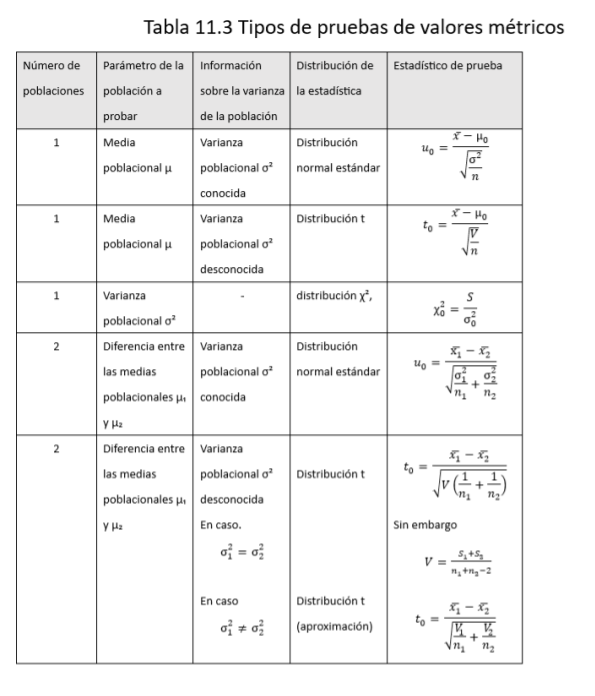

```python
from IPython.display import Image, display

display(Image(filename='./Graph2/Tabla4_2.png'))
```

### 2. Estimación e inferencia sobre una medida poblacional (**con varianza conocida**)

１つの母平均に関する検定と推定（母分散既知の場合）

[Audio_6](https://drive.google.com/file/d/1gubh_dqHRgKp2qF8HQUfUl4aoY-POMT4/view?usp=drive_link)

## 4.1

あるラインで製造される接着剤の接着強度の母平均は $ 10.0(N/mm^2) $、母分散は $ 0.5^2 (N/mm^2)^2 $ であった。今回、顧客から接着剤の接着強度の向上が求められたので、工程を改善し、接着強度が向上したかどうかを調べたい。改善した工程で製造した試作品９個の接着強度を測定したところ、その平均値は $ 11.0 (N/mm^2) $ であった。母分散は変化しないとして接着剤の接着強度が高くなったかどうかを調査する。

La media poblacional de la resistencia de adhesión de un adhesivo producido en una determinada línea de fabricación era de $ 10.0(N/mm^2) $, y la varianza poblacional era de $ 0.5^2 (N/mm^2)^2 $.

En esta ocasión, un cliente solicitó una mejora en la resistencia de adhesión del adhesivo, por lo que se mejoró el proceso de producción y se desea verificar si la resistencia ha aumentado.

Se midió la resistencia de adhesión de **9 muestras** producidas con el nuevo proceso mejorado, y el valor medio obtenido fue de $ 11.0 (N/mm^2) $.

Suponiendo que la varianza poblacional no ha cambiado, se investigará si la resistencia de adhesión del adhesivo ha aumentado.

Paso 1: Establecimiento de la hipótesis nula H0 y la hipótesis alternativa H1. 仮説の設定と有意水準

$ H_0 : \mu = \mu_0 \qquad (\mu_0 = 10.0)$

$ H_1 : \mu > \mu_0 $

$ \alpha = 0.05 $

```python
import scipy.stats as stats

# Parámetros conocidos
mu_0 = 10.0             # Media poblacional bajo la hipótesis nula H0
sigma2 = 0.5**2           # Varianza poblacional conocida
sigma = np.sqrt(sigma2) # Desviación estándar poblacional
n = 9                   # Tamaño de la muestra
x_bar = 11.0            # Media muestral

alpha = 0.05            # Nivel de significancia
```

Paso 2: Establecimiento de la región de rechazo 棄却域の設定

$ R: u_0 \geq u(0.10) = 1.645 $

```python
u_critico = stats.norm.ppf(1 - alpha)

print(f"Valor crítico (α={alpha:.2f}): {u_critico:.3f}")
```

```
Valor crítico (α=0.05): 1.645
```

Paso 3: Cálculo del estadístico de prueba. 検定統計量の計算

$ u_0 = \frac{\bar{x}-u_0}{\sqrt{\sigma^2/n}} $

```python
u0 = (x_bar - mu_0) / (sigma / np.sqrt(n))
print(f"Estadístico u0: {u0:.3f}\n")
```

```
Estadístico u0: 6.000
```

Paso 4: Conclusión 判定

$ u_0 = 6.000 > u(0.10) = 1.645 $

De lo anterior, se concluye que hay **significancia estadistica**.

Es decir, con un nivel de significancia del 5%, se puede afirmar que la resistencia adhesiva del pegamento ha aumentado.

```python
# Cálculo del valor p (p-value)
p_value = 1 - stats.norm.cdf(u_critico)
print(f"Valor p: {p_value:.6f}")

if u0 > u_critico:
    print("Se rechaza la hipótesis nula. Se concluye que la resistencia ha mejorado.")
else:
    print("No se puede rechazar la hipótesis nula. No hay evidencia suficiente de mejora.")
```

[output not shown]

Paso 5: Estimación de la media poblacional 母平均の推定

Estimación puntual：点推定

$ \hat{x} = \bar{x} = 11.0 (N/mm^2) $

Estimación por intervalo con un nivel de confianza del 95%：信頼率９５％の区間推定

$ \bar{x} \pm u(0.05)\frac{\sigma}{\sqrt{n}} = 11.0 \pm 1.960 \times \frac{0.5}{\sqrt{9}} = 11.0 \pm 0.33 = 10.67, 11.33 (N/mm^2) $

De la fórmula de la estimación por intervalos, el ancho del intervalo de confianza se reduce a medida que aumenta el tamaó de la muestra y a medida que disminuye la desviación estándar.

```python
# Parámetros conocidos
media_muestral = x_bar           # Media muestral observada
media_hipotetica = mu_0        # Media poblacional anterior
varianza_poblacional = sigma2     # Varianza poblacional conocida

# Estimación puntual de la media poblacional
print("Estimación puntual de la media poblacional:")
print(f"Media poblacion ≈ {media_muestral:.1f} N/mm²")

# Nivel de confianza
confianza = 0.95
alpha = 1 - confianza

# Valor crítico u para intervalo de confianza bilateral
u_critico = stats.norm.ppf(1 - alpha / 2)

# Margen de error
margen_error = u_critico * sigma / np.sqrt(n)

# Intervalo de confianza
limite_inferior = media_muestral - margen_error
limite_superior = media_muestral + margen_error

print(f"\nIntervalo de confianza del {int(confianza*100)}% para la media poblacional:")
print(f"({limite_inferior:.2f}, {limite_superior:.2f}) N/mm²")
```

```
Estimación puntual de la media poblacional:
Media poblacion ≈ 11.0 N/mm²

Intervalo de confianza del 95% para la media poblacional:
(10.67, 11.33) N/mm²
```

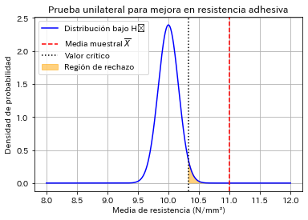

```python
# Visualización del resultado

x = np.linspace(8, 12, 500)  # Rango de valores para el eje x
y = stats.norm.pdf(x, mu_0, sigma / np.sqrt(n))  # Densidad bajo H0

# Dibujar la curva de distribución bajo H0
plt.plot(x, y, label='Distribución bajo H₀', color='blue')

# Línea de la media muestral
plt.axvline(x_bar, color='red', linestyle='--', label=r'Media muestral $\overline{X}$')

# Línea del valor crítico
plt.axvline(mu_0 + u_critico * sigma / np.sqrt(n), color='black', linestyle=':', label='Valor crítico')

# Rellenar la región de rechazo (zona crítica)
x_fill = np.linspace(mu_0 + u_critico * sigma / np.sqrt(n), 12, 200)
plt.fill_between(x_fill, stats.norm.pdf(x_fill, mu_0, sigma / np.sqrt(n)), color='orange', alpha=0.5, label='Región de rechazo')

# Etiquetas y leyenda
plt.title("Prueba unilateral para mejora en resistencia adhesiva")
plt.xlabel("Media de resistencia (N/mm²)")
plt.ylabel("Densidad de probabilidad")
plt.legend()
plt.grid(True)
plt.show()
```

### 3. Prueba y estimación de una media poblacional (cuando la **varianza poblacional es desconocida**)

１つの母平均に関する検定と推定（母分散未知の場合）

[Audio_7](https://drive.google.com/file/d/1jLNWgKCO3he3j0gsJfjoANOs8Dzfd3bM/view?usp=drive_link)

## 4.2

特殊ベルトを製造している工程で、従来の特殊ベルトの伸長時応力の母平均は $ 2.0(MP_a) $ であった。今回、新製品に装着する特殊ベルトの伸長時応力を向上させたいとの要望が納入先よりあり、原材料や工程の改善を行った。そこで試作の特殊ベルト９個について伸長時応力を測定したところ表４．３のデータを得た。特殊ベルトの伸長時応力が向上したか調べたい。

En el proceso de fabricación de correas especiales, la media poblacional de la tensión de elongación de las correas especiales tradicionales era de $ 2.0(MP_a) $. Recientemente, el cliente ha solicitado mejorar la tensión de elongación de las correas especiales para un nuevo producto. Se realizaron mejoras en los materiales y en el proceso. Se midió la tensión de elongación de 9 correas especiales de prueba y se obtuvieron los datos mostrados en la tabla 4.3. Ahora, se desea investigar si la tensión de elongación de las correas especiales ha mejorado.

```python
SERVICE_ACCOUNT_FILE = "my-project-vscode-452201-249bdb033f8c.json"  # JSONファイルのパス
SCOPES = ["https://www.googleapis.com/auth/spreadsheets"]

credentials = Credentials.from_service_account_file(SERVICE_ACCOUNT_FILE, scopes=SCOPES)
client = gspread.authorize(credentials)

# スプレッドシートを開く（URLまたはスプレッドシートIDを使用）
SPREADSHEET_ID = "1W4H3VxXJwpKGMu0rE9ocz6yA6J0boG9vGzktgsro1es"
sheet = client.open_by_key(SPREADSHEET_ID).worksheet("Sheet5") # 最初のシートを取得

# データを取得
list_of_lists = sheet.get_all_records()
df = pd.DataFrame(list_of_lists)

df = df.set_index("No")
df = df.astype(float)

muestra = df.to_numpy()[:,:1]

print(df)
```

```
      x   x^2
No
1   3.0   9.0
2   4.0  16.0
3   2.0   4.0
4   2.0   4.0
5   4.0  16.0
6   4.0  16.0
7   5.0  25.0
8   1.0   1.0
9   2.0   4.0
```

Paso 1: Establecimiento de la hipótesis nula H0 y la hipótesis alternativa H1. 仮説の設定と有意水準

$ H_0 : \mu = \mu_0 \qquad (\mu_0 = 2.0) $

$ H_1 : \mu_ > \mu_0 $

$ \alpha = 0.05 $

```python
import scipy.stats as stats

muestra = df.to_numpy()[:,:1] # Sample

# Parámetros conocidos
media_poblacional = 2.0  # Media poblacional de la tensión de elongación
n = len(muestra)         # Tamaño de la muestra
media_muestral = np.mean(muestra)  # Media muestral
desviacion_muestral = np.std(muestra, ddof=1)  # Desviación estándar muestral

# Valor crítico t para un nivel de confianza del 95%
alpha = 0.05
```

Paso 2: Establecimiento de la región de rechazo 棄却域の設定

$ R: t_0 \geq t(\phi, 2\alpha ) $

```python
# Grados de libertad
df = n - 1

t_critico = stats.t.ppf(1 - alpha, df)
print(f"Valor crítico t para un nivel de significancia de {alpha:.3f}: {t_critico:.3f}")
```

```
Valor crítico t para un nivel de significancia de 0.050: 1.860
```

Paso 3: Calculo del estadístico de prueba 検定統計量の計算

$ t_0 = \frac{\bar{x} - u_0}{\sqrt{V/n}} $

```python
t_stat = (media_muestral - media_poblacional) / (desviacion_muestral / np.sqrt(n))

print(f"Media muestral: {media_muestral:.2f}")
print(f"Desviacion estandar muesral: {desviacion_muestral:.2f}")
print(f"Estadístico t: {t_stat:.3f}")
```

```
Media muestral: 3.00
Desviacion estandar muesral: 1.32
Estadístico t: 2.268
```

Paso 4: Coclusion 判定

$ t_0 = 2.268 > t(8,0.10) = 1.860 $

De lo anterior, se concluye que hay significancia estadística. Es decir, con un nivel de significancia 5%, se puede afirmar que el esfuerzo de elengación de la banda especial ha mejorado.

```python
# Decisión de rechazo o no de la hipótesis nula
if t_stat > t_critico:
    print("Se rechaza la hipótesis nula: La tensión de elongación ha mejorado.")
else:
    print("No se rechaza la hipótesis nula: No hay suficiente evidencia para afirmar que la tensión de elongación ha mejorado.")
```

```
Se rechaza la hipótesis nula: La tensión de elongación ha mejorado.
```

Paso 5: Estimación de la media poblacional 母平均の推定

Estimación puntual

$ \hat{x} = \bar{x} = 3.00 (MPa) $

Estimación por intervalo con un nivel de confianza de 95%

$ \bar{x} \pm t(\phi, 0.05) \sqrt{V/n} = 3.00 \pm t(8, 0.05) \sqrt{1.75/9} = 3.00 \pm 2.306 \sqrt{1.75 / 9} = 1.98, 4.02 (MPa) $

```python
# Cálculo de la estimación puntual (media muestral)
print(f"Estimación puntual de la media: {media_muestral:.2f} MPa")

# Cálculo de la estimación por intervalo (intervalo de confianza)
# Nivel de confianza 95% (alpha = 0.05)
alpha = 0.05

# Calcular el error estándar
error_estandar = desviacion_muestral / np.sqrt(n)

# Calcular el valor t crítico para un intervalo de confianza del 95%
t_critico = stats.t.ppf(1 - alpha / 2, n - 1)  # 2 cola

# Calcular el intervalo de confianza
margen_error = t_critico * error_estandar
intervalo_confianza = (media_muestral - margen_error, media_muestral + margen_error)

print(f"Intervalo de confianza del 95% para la media: ({intervalo_confianza[0]:.2f}, {intervalo_confianza[1]:.2f}) MPa")
```

```
Estimación puntual de la media: 3.00 MPa
Intervalo de confianza del 95% para la media: (1.98, 4.02) MPa
```

１つの母分散に関する検定と推定

[Audio_7](https://drive.google.com/file/d/1jLNWgKCO3he3j0gsJfjoANOs8Dzfd3bM/view?usp=drive_link)

## 4.3

3Dプリンター用の精密部品を製造している工程で、最近、重要箇所の寸法のバラつきを小さくするために、工程を改善することになった。従来の寸法のバラつきは母分散 $ 2.0^2 (\mu m)^2 $ であったが、今回、改善した工程で、９ロットを試作して、表4.4の結果を得た。寸法の母分散が従来よりも小さくなったかどうか調べたい。

En el proceso de fabricación de piezas de precisión para impresoras 3D, recientemente se decidió mejorar el proceso para reducir la variablidad en las dimensiones de puntos clave. La variabilidad de las dimensiones en el proceso anterior era una varianza poblacional de $ 2.0^2 (\mu m)^2 $. Sin embargo, en el proceso mejorado, se realizaron 9 lotes de prueba, obteniendo los resultados de la tabla 4.4. Se desea investigar si la varianza de las dimensiones ha disminuido en comparación con el proceso anterior.

```python
sheet = client.open_by_key(SPREADSHEET_ID).worksheet("Sheet6") # 最初のシートを取得

list_of_lists = sheet.get_all_records()
df = pd.DataFrame(list_of_lists)

df.set_index('Lote', inplace=True)
df = df.astype('float')

datos = df.to_numpy()[:,:1]

print("Tabla 4.4")
print(df)
```

```
Tabla 4.4
         x     x^2
Lote
1     31.0   961.0
2     32.0  1024.0
3     34.0  1156.0
4     33.0  1089.0
5     31.0   961.0
6     33.0  1089.0
7     32.0  1024.0
8     34.0  1156.0
9     33.0  1089.0
```

Paso 1: Establecimiento de la hipótesis nula H0 y la hipótesis alternativa H1. 仮説の設定と有意水準

$ H_0 : \sigma^2 = \sigma_0^2 \qquad (\sigma_0^2 = 2.0^2) $

$ H_1 : \sigma^2 < \sigma_0^2 $

$ \alpha = 0.05 $

```python
media_muestral = np.mean(datos)  # Media muestral
varianza_muestral = np.var(datos, ddof=1)  # Varianza muestral (ddof=1 para obtener la varianza muestral)
tamaño_muestra = len(datos)  # Número de muestras

alpha = 0.05  # Nivel de significancia
```

Paso 2: Establecimiento de la región de rechazo 棄却域の設定

```python
# Grados de libertad
grados_libertad = tamaño_muestra - 1

# Valor crítico para el test chi-cuadrado (prueba de una cola, porque queremos ver si la varianza es menor)
valor_critico = stats.chi2.ppf(alpha, grados_libertad)

print(f'Valor critico: {valor_critico:.2f}')
```

```
Valor critico: 2.73
```

Paso 3: Cálculo del estadístico de prueba 検定統計量の計算

$ \chi_0^2 = \frac{S}{\sigma_0^2} = 2.56 $

```python
# Establecer el valor de la varianza poblacional bajo H0
varianza_bajo_H0 = 2.0**2

S = np.sum((datos - media_muestral)**2)
print(f"Suma de Cuadrados (S): {S:.2f}")

# Realizar la prueba de chi-cuadrado
estadistico_chi2 = (tamaño_muestra - 1) * varianza_muestral / varianza_bajo_H0

print(f"Estadístico chi-cuadrado: {estadistico_chi2:.2f}")
```

```
Suma de Cuadrados (S): 10.22
Estadístico chi-cuadrado: 2.56
```

Paso 4: Determinacion 判定

$ \hat{\sigma}^2 = 2.56 < \chi^2(\phi, 1-0.05) = 2.73 $

De lo anterior, se concluye que hay significancia estadística.

Es decir, con un nivel de significanica del 5%, se puede afirmar que la varíabilidad dimensional es menor que la anterior.

```python
# Determinar si rechazamos H0
if estadistico_chi2 < valor_critico:
    print("Se rechaza H0: La varianza ha disminuido.")
else:
    print("No se rechaza H0: No hay evidencia suficiente para decir que la varianza ha disminuido.")
```

```
Se rechaza H0: La varianza ha disminuido.
```

Paso 5: Estimación de la media poblacional 母分散の推定

Estimación puntual

$ \hat{\sigma}^2 = V = \frac{S}{n-1} = 1.28 = 1.13^2 (\mu m)^2 $

Estimación por intervalo con un nivel de confianza del 95%

$ \delta_L^2 = S / (\chi^2(\phi, \alpha/2) = S / \chi^2(9-1, 0.025) = 10.22 / 17.53 = 0.583 = 0.764^2 (\mu m)^2 $

$ \delta_U^2 = S / (\chi^2(\phi, 1-\alpha/2) = S / \chi^2(9-1, 0.975) = 10.22 / 2.18 = 4.688 = 2.165^2 (\mu m)^2 $

```python
# Estimación puntual de la varianza (utilizando la varianza muestral como estimación de la varianza poblacional)
print(f"Varianza muestral: {np.sqrt(varianza_muestral)=:.2f}^2 (um)^2")

# Estimación por intervalo de confianza para la varianza
# Intervalo de confianza al 95% para la varianza
chi2_inf = stats.chi2.ppf(alpha / 2, grados_libertad)
chi2_sup = stats.chi2.ppf(1 - alpha / 2, grados_libertad)

# Calcular el intervalo de confianza para la varianza
ic_varianza_inf = (tamaño_muestra - 1) * varianza_muestral / chi2_sup
ic_varianza_sup = (tamaño_muestra - 1) * varianza_muestral / chi2_inf

print(f"Intervalo de confianza del 95% para la varianza: ({np.sqrt(ic_varianza_inf):.3f}^2, {np.sqrt(ic_varianza_sup):.3f}^2)")
```

```
Varianza muestral: np.sqrt(varianza_muestral)=1.13^2 (um)^2
Intervalo de confianza del 95% para la varianza: (0.764^2, 2.166^2)
```

### 5. Prueba e inferencia sobre **la razón de dos varianzas poblacionales**

２つの母分散の比に関する検定と推定

[Audio_9](https://drive.google.com/file/d/1fHcFwQ6ykCB6mpXR2U2eftwZrgFoMmEz/view?usp=drive_link)

## 4.4

バネを製作している工程がある。最近、バネの内径のバラつきが大きいとの指摘があり社内で検討した結果、製造ラインによって差があるのではないかという意見が出されたので、A、Bの２つのラインで製造されるバネの内径 (mm)のバラつきに差があるかを調査することにした。両ラインからそれぞれ１１個のサンプルをとり、得られたデータから平方和を計算したところ、Aラインでは $ 130.0(mm)^2 $、Bラインでは $ 100.0 (mm)^2 $となった。

En un proceso de fabricación de resortes, recientemente se señaló que existe una gran variabilidad en el diámetro interior de los resortes. Tras una revisión interna, surgió la hipótesis de que podría haber diferencias entre las líneas de producción. Por ello, se decidió investigar si existe una diferencia en la variabilidad del diámetro interior (mm) de los resortes fabricados en dos líneas, A y B. Se tomaron 11 muestras de cada línea, y al calcular la suma de cuadrados de los datos obtenidos, se obtuvo un valor de $ 130.0(mm)^2 $ para línea A y $ 100.0 (mm)^2 $ para la línea B.

Paso 1: Establecimiento de la hipótesis nula H0 y la hipótesis alternativa H1. 仮説の設定と有意水準

$ H_0 : \sigma_A^2 = \sigma_B^2 $

$ H_0 : \sigma_A^2 \neq \sigma_B^2 $

$ \alpha = 0.05 $

```python
import scipy.stats as stats

# Datos
n1 = 11  # Tamaño de muestra de la línea A
n2 = 11  # Tamaño de muestra de la línea B
S1_sq = 130.0  # Suma de cuadrados de la línea A
S2_sq = 100.0  # Suma de cuadrados de la línea B

alpha = 0.05
```

Paso 2: Establecimiento de la regi[on de rechazo 棄却域の設定

$ R: F_0 = F(n_A-1, n_B-1: 0.05/2) = F(10,10:0.025) $

```python
## Estimación puntual del cociente de varianzas
var_ratio = S1_sq / S2_sq

# Prueba F: H0: σ1² = σ2²  vs H1: σ1² ≠ σ2² (prueba bilateral)
F = var_ratio
df1 = n1 - 1
df2 = n2 - 1

# Valor crítico para nivel de significancia alfa = 0.05
F_crit_high = stats.f.ppf(1 - alpha / 2, df1, df2)
F_crit_low = stats.f.ppf(alpha/2,df1,df2)

print(f"Valores críticos para α=0.05: F = {F_crit_high:.2f}")
```

```
Valores críticos para α=0.05: F = 3.72
```

Paso 3: Cálculo del estadístico de prueba 統計量の計算

$ F_0 = V_A / V_B $

```python
print(f"Estimación puntual de la razón de varianzas F0 (σ1²/σ2²): {var_ratio:.2f}")
```

```
Estimación puntual de la razón de varianzas F0 (σ1²/σ2²): 1.30
```

Paso 4: Conclusión 判定

$ F_0 = 1.30 < F(10,10:0.025) = 3.72 $

De lo anterior, se concluye que no hay significancia estadística.

Es cedir, con un nivel de significancia 5%, no se puede afirmar que la variabilidad del diámetro interior de los resortes de ambos líneas sea diferente.

```python
# Decisión sobre H0
if F < F_crit_low or F > F_crit_high:
    print("Se rechaza H0: Hay evidencia de que las varianzas son diferentes.")
else:
    print("No se rechaza H0: No hay evidencia suficiente de diferencia en varianzas.")
```

```
No se rechaza H0: No hay evidencia suficiente de diferencia en varianzas.
```

Paso 5: Estimación de la media población. 母分散の比の推定

Estimación puntual

$ \hat{\sigma_A}^2 / \hat{\sigma_B}^2 = V_A /V_B = 1.30 $

Estimación por intervalo con un nivel de confianza del 95%

$ V_A / V_B \times F(\phi_A, \phi_B: 1-\alpha/2) = 0.349 $

$ V_A / V_B \times F(\phi_A, \phi_B: \alpha/2) = 4.836 $

```python
print(f"Estadístico F calculado: {F:.2f}")

# Estimación por intervalo de confianza para la razón de varianzas
IC_bajo = var_ratio / stats.f.ppf(1 - alpha / 2, df1, df2)
IC_alto = var_ratio / stats.f.ppf(alpha / 2, df1, df2)

print(f"Intervalo de confianza del 95% para σ1² / σ2²: [{IC_bajo:.3f}, {IC_alto:.3f}]")
```

```
Estadístico F calculado: 1.30
Intervalo de confianza del 95% para σ1² / σ2²: [0.350, 4.832]
```

### 6. Prueba y estimación de la diferencia entre **dos medias poblacionales** (**varianzas poblacionales desconocidas**)

２つの母平均の差に関する検定・推定（母分散未知の場合）

[Audio_10](https://drive.google.com/file/d/1Beymfl8hhhXykVdEYxROxjGuQZwUJacm/view?usp=drive_link)

## 4.5

レトルト食品を製造している工程がある。最近、レトルト食品のとろみ（特性値：粘度）がばらついているのではないかとの問合せが顧客からあった。検討した結果、製造ラインによって、とろみが異なるのではないかという意見があり調査することにした。A、Bの２つのラインからそれぞれ９個のサンプルをとり、粘度（パスカル秒）を測定した。ライン間でとろみの母平均に差があるか検証する。

En el proceso de fabricación de alimentos envasados al vacío (reportados), se recibió recientemente una consulta de un cliente respecto a que la viscosidad (valor característico) de los productos podría estar mostrando una variabilidad excesiva. Tras una revisión interna, surgió la hipótesis de que la viscosidad podría estar variando según la línea de producción. Por ello, se decidió realizar una investigación tomando 9 muestras de cada una de las dos líneas de producción, A y B, y se midió la viscosidad (en pascal-segundos). Se procederá a verificar si existe una diferencia en la media poblacional de la viscosidad entre las dos líneas.

```python
sheet = client.open_by_key(SPREADSHEET_ID).worksheet("Sheet7") # 最初のシートを取得

# データを取得
list_of_lists = sheet.get_all_records()
df = pd.DataFrame(list_of_lists)

df.set_index('No', inplace=True)
df = df.astype('float')

data = df.to_dict()

print(df)
```

```
      XA    XB
No
1   71.0  66.0
2   72.0  70.0
3   80.0  75.0
4   81.0  68.0
5   75.0  70.0
6   78.0  65.0
7   73.0  63.0
8   72.0  63.0
9   70.0  60.0
```

Paso 1: Establecimiento de la hipótesis nula $ H_0 $ y la hipótesis alternativa $ H_1 $. 仮説の設定と有意水準

$ \alpha = 0.05 $

```python
# Convertimos los valores a listas numéricas
XA = np.array(list(data['XA'].values()), dtype=float)
XB = np.array(list(data['XB'].values()), dtype=float)

alpha = 0.05
```

Paso 2: Establecimiento de la regi[on de rechazo 棄却域の設定

$ \phi = n_A + n_B -2 = 16 $

$ R: |t_0| \geq t(\phi, \alpha) = 2.120 $

```python
# Tamaños de muestra
nA = len(XA)
nB = len(XB)

# Grados de libertad
gl = nA + nB - 2

t0 = stats.t.ppf(1 - alpha/2, df=gl)

print(f"Grados de libertad: {gl}")
print(f"Valor crítico t: {t0:.3f}")
```

```
Grados de libertad: 16
Valor crítico t: 2.120
```

Paso 3: Cálculo del estadístico de prueba 検定統計量の計算

$ \bar{x}_A = 74.67 $, $ V_A = 16.50 $

$ \bar{x}_B = 66.67 $, $ V_B = 21.00 $

Al comparar $ V_A $ y $ V_B $, dado que la razón de las varianzas fue de dos veces (o menos), se aplicará la prueba $ t $.

$ \frac{V_B}{V_A} = 1.27 $

$ t_0 = (\bar{x}_A -\bar{x}_B)/ \sqrt{V(1/n_A + 1/n_B)} = 3.919 $

```python
# Medias y varianzas muestrales
mediaA = np.mean(XA)
mediaB = np.mean(XB)
varA = np.var(XA, ddof=1)  # varianza muestral
varB = np.var(XB, ddof=1)

# Estimación puntual de la diferencia de medias
dif_medias = mediaA - mediaB

# Varianza combinada (cuando se asume σA^2 = σB^2)
var_combinada = ((nA - 1) * varA + (nB - 1) * varB) / (nA + nB - 2)
se = np.sqrt(var_combinada * (1/nA + 1/nB))

# Estadístico t
t_stat = dif_medias / se

# Mostrar resultados

print(f"Comparación de VA y VB: {varB/varA:.2f}")
print(f"Media Línea A: {mediaA:.2f}, Varianza: {varA:.2f}")
print(f"Media Línea B: {mediaB:.2f}, Varianza: {varB:.2f}\n")
print(f"Estadístico t0: {t_stat:.3f}")
```

```
Comparación de VA y VB: 1.27
Media Línea A: 74.67, Varianza: 16.50
Media Línea B: 66.67, Varianza: 21.00

Estadístico t0: 3.919
```

Paso 4: Conclusión 判定

$ | t_0 | = 3.919 > t(16, 0.05) = 2.120 $

De lo anterior, se concluye que hay significancia estadística.

Es decir, con un nivel de significancia del 5%, se puede afirmar que existe una diferencia en la viscosidad.

```python
if t_stat > t0:
   print(f"t0 = {t_stat:.3f} > t(16, 0.05) = {t0:.3f}")
   print("⇒ Se rechaza la hipótesis nula: hay diferencia significativa entre las medias.")
else:
    print(f"t0 = {t_stat:.3f} < t(16, 0.05) = {t0:.3f}")
    print("⇒ No se puede rechazar la hipótesis nula: no hay evidencia de diferencia significativa.")

# Valor p (bilateral)
p_valor = 2 * (1 - stats.t.cdf(abs(t_stat), df=gl))
```

```
t0 = 3.919 > t(16, 0.05) = 2.120
⇒ Se rechaza la hipótesis nula: hay diferencia significativa entre las medias.
```

Paso 5: Estimación de la media probacional 母平均の差の推定

Estimación puntual

$ \hat{\mu}_A - \hat{x}_B = \bar{x}_A - \bar{x}_B = 8.0 $

Estimaci[on por intervalo con un nivel de confianza del 95%

$ (\bar{x}_A - \bar{x}_B) \pm t(\phi, \alpha) \sqrt{V(1/n_A + 1/n_B)} $

```python
# Intervalo de confianza del 95%
nivel_confianza = 0.95
t_critico = stats.t.ppf(1 - (1 - nivel_confianza)/2, df=gl)
lim_inf = dif_medias - t_critico * se
lim_sup = dif_medias + t_critico * se

print(f"Diferencia de medias (estimación puntual): {dif_medias:.2f}")
print(f"Intervalo de confianza del 95%: ({lim_inf:.2f}, {lim_sup:.2f})")
```

```
Diferencia de medias (estimación puntual): 8.00
Intervalo de confianza del 95%: (3.67, 12.33)
```

### 7. Prueba y estimación de la diferencia entre dos medias poblacionales (prueba de Welch)

２つの母平均の差に関する検定・推定（Welchの検定の場合）

[Audio_11](https://drive.google.com/file/d/1_j4cStvy0SoF20JkcGlHDCl535m3KlzJ/view?usp=drive_link)

## 4.6

A、Bの二つのラインで機械溶接された部品の引張強度（MPa）の母平均に差があるのはないかとの指摘が検査工程からあり、調査することになった。A、Bラインからそれぞれ９個のサンプルを採取し、表４．６のデータを得た。A、Bラインでの引張強度の母平均に差があるかWelchの検定を行え。

Se recibió una observación desde el área de inspección de que podría haber una diferencia en las medias poblacionales de la resistencia a la tracción (MPa) de las piezas soldadas por máquina en las líneas A y B. Por ello, se decidió realizar una investigación. Se tomaron 9 muestras de cada una de las líneas A y B, y se obtuvieron los datos mostrados en la Tabla 4.6. Realice la prueba de Welch para verificar si hay una diferencia en las medias poblacionales de la resistencia a la tracción entre las líneas A y B.

```python
sheet = client.open_by_key(SPREADSHEET_ID).worksheet("Sheet8") # 最初のシートを取得

# データを取得
list_of_lists = sheet.get_all_records()
df = pd.DataFrame(list_of_lists)

df.set_index('No', inplace=True)
df = df.astype('float')

data = df.to_dict()

print("Tabla 4.6")
print(df)
```

```
Tabla 4.6
      XA    XB
No
1   15.0  14.0
2   20.0  19.0
3   20.0   4.0
4   26.0   5.0
5   21.0   5.0
6   25.0  19.0
7   15.0   8.0
8   16.0   5.0
9   20.0  14.0
```

Paso 1: Establecimiento de la hipótesis nula H0 y la hipótesis alternativa H1. 仮説の設定と有意水準

$ H_0 : \mu_A = \mu_B $

$ H_1 : \mu_A \neq \mu_B $

$ \alpha = 0.05 $

```python
import scipy.stats as stats

# Convertimos los valores a listas numéricas
XA = np.array(list(data['XA'].values()), dtype=float)
XB = np.array(list(data['XB'].values()), dtype=float)

# Tamaños de muestra
nA = len(XA)
nB = len(XB)
```

Paso 2: Establecimiento de la región de rechazo.

$ R: |t_0| \geq t(\phi^{*}, \alpha) $

Paso 3: Cálculo del estadístico de prueba

Realizar la **prueba de Welch**

```python
# Cálculo de medias y desviaciones estándar
media_XA = np.mean(XA)
media_XB = np.mean(XB)
desv_XA = np.std(XA, ddof=1)
desv_XB = np.std(XB, ddof=1)

# Estimación puntual de la diferencia de medias (media_XA - media_XB)
estimacion_puntual = media_XA - media_XB

# Realizamos la prueba de Welch (t-test sin suposición de igual varianza)
t_stat, p_valor = stats.ttest_ind(XA, XB, equal_var=False)

# Mostrar resultados
print("=== Comparación de medias mediante la prueba de Welch ===")
print(f"Media Línea A: {media_XA:.2f}")
print(f"Media Línea B: {media_XB:.2f}")

print(f"\nEstadístico t: {t_stat:.4f}")
```

```
=== Comparación de medias mediante la prueba de Welch ===
Media Línea A: 19.78
Media Línea B: 10.33

Estadístico t: 3.8399
```

Paso 4: Concluson 判定

Por lo tanto, es significativo.

Es decir, con un nivel de significancia del 5%, se puede afirmar que existe una diferencia en las medias poblacionales de la resistencia a la tracción de la soldadura.

```python
# Nivel de confianza del 95%
alpha = 0.05
t_critico = stats.t.ppf(1 - alpha/2, df=gl)

# Grados de libertad según Welch–Satterthwaite
s2A = np.var(XA, ddof=1)
s2B = np.var(XB, ddof=1)

gl = (s2A/nA + s2B/nB)**2 / ((s2A**2)/((nA**2)*(nA-1)) + (s2B**2)/((nB**2)*(nB-1)))

print(f"Grados de libertad (Welch): {gl:.2f}")
print(f"Valor p: {p_valor:.4f}")

if p_valor < alpha:
    print("⇒ Hay una diferencia significativa entre las medias (rechazamos H0).")
else:
    print("⇒ No hay evidencia suficiente para afirmar que las medias difieren (no se rechaza H0).")
```

```
Grados de libertad (Welch): 13.66
Valor p: 0.0019
⇒ Hay una diferencia significativa entre las medias (rechazamos H0).
```

Paso 5: Estimación de la media poblacional 母平均の差の推定

Estimación puntual

$ \hat{x}_A - \hat{x}_B = \bar{x}_A -\bar{x}_B = 9.44 $

Estimación por intervalo con un nivel de confiazanza del 95%

$ (\bar{x}_A - \bar{x}_B) \pm t(\phi^*, \alpha) \sqrt{V_A/n_A + V_B/n_B} $

```python
# Cálculo del error estándar de la diferencia de medias
se_dif = np.sqrt(s2A/nA + s2B/nB)

# Intervalo de confianza
lim_inf = estimacion_puntual - t_critico * se_dif
lim_sup = estimacion_puntual + t_critico * se_dif

print(f"Diferencia de medias (estimación puntual): {estimacion_puntual:.2f}")
print(f"Intervalo de confianza del 95% para la diferencia de medias: ({lim_inf:.2f}, {lim_sup:.2f})")
```

```
Diferencia de medias (estimación puntual): 9.44
Intervalo de confianza del 95% para la diferencia de medias: (4.23, 14.66)
```

### 8. Prueba y estimación de la diferencia de medias poblacionales en datos apareados (varianza poblacional desconocida)

データに対応がある場合の母平均の差の検定と推定（母分散未知の場合）

[Audio_12](https://drive.google.com/file/d/1fQ45ydsoVWm9ZMc0rZiodxapaRgR3-Cr/view?usp=drive_link)

## 4.7

ある会社では、新規化合物を開発している。新規化合物の重要特性である不純物量（％）の判定において、測定法A法とB法との間に偏り（母平均の差）があるかどうかを判定したい。そこで、９種の異なる新規化合物を用意し、A法およびB法で測定して得たデータを表４．７に示す。不純物量の測定法A法およびB法で違いがあるか調べよ。

Una empresa está desarrollando nuevos compuestos. Para evaluar si existe un sesgo (una diferencia en las medias poblacionales) entre el método de medición A y el método B en la determinación de una característica importante --el porcentaje de impurezas (%)-- de un nuevo compuesto, se desea realizar una prueba estadística. Para ello, se han preparado nueve tipos diferentes de nuevos compuestos, y se han obtenido los datos de medición utilizando ambos métodos, A y B. Los resultados se muestran en la Tabla 4.7. ¿Existe alguna diferencia entre los métodos de medición A y B en cuanto al porcentaje de impurezas?

```python
sheet = client.open_by_key(SPREADSHEET_ID).worksheet("Sheet9") # 最初のシートを取得

# データを取得
list_of_lists = sheet.get_all_records()
df = pd.DataFrame(list_of_lists)

df.set_index('No', inplace=True)
df = df.astype('float')

data = df.to_dict()

print("Tabla 4.7:")
print(df)
```

```
Tabla 4.7:
       A     B
No
1   2.05  2.04
2   2.10  2.09
3   2.10  1.94
4   2.16  1.95
5   2.01  1.95
6   2.15  2.09
7   2.05  1.98
8   2.06  1.95
9   2.10  2.04
```

Al crear un gráfico basado en la Tabla 4.7, se puede observar que existe una correspondencia con el tipo de compuesto.

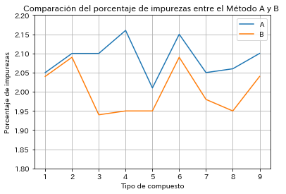

```python
df.plot(kind='line')
plt.ylim(1.8,2.2)
plt.grid(True)
plt.title('Comparación del porcentaje de impurezas entre el Método A y B ')
plt.xlabel('Tipo de compuesto')
plt.ylabel('Porcentaje de impurezas')
plt.show()
```

Paso 1: Establecimiento de la hipótesis nula H0 y la hipótesis alternativa H1. 仮説の設定と有意水準

$ H_0 : \delta = 0 $

$ H_1 : \delta \neq 0 $

$ \alpha = 0.05 $

Paso 2: Establecimiento de la región de rechazo 棄却域の設定

$ R: |t_0| \geq t(\phi, \alpha) = 2.306 $

```python
# Nivel de confianza del 95%
alpha = 0.05
gl = len(df) - 1
t_critico = stats.t.ppf(1 - alpha/2, df=gl)

print(f"Grados de libertad: {gl}")
print(f"Valor crítico t: {t_critico:.3f}")
```

```
Grados de libertad: 8
Valor crítico t: 2.306
```

Paso 3: Cálculo del estadístico de prueba 検定統計量の計算 データの差の平均値の計算

$ \bar{d} = \frac{\sum di}{n} = 0.0833 $

$ t_0 = \bar{d} / \sqrt{V_d/n} = 3.769 $

```python
# Realizamos la prueba t para muestras relacionadas (pareadas)
# H0: no hay diferencia entre los métodos A y B (media de las diferencias = 0)
# H1: hay una diferencia significativa entre los métodos A y B
t_stat, p_valor = stats.ttest_rel(df['A'], df['B'])

# Mostramos los resultados de la prueba
print("\nResultado de la prueba t para muestras pareadas:")
print(f"Estadístico t = {t_stat:.4f}")
```

```
Resultado de la prueba t para muestras pareadas:
Estadístico t = 3.7689
```

Paso 4: Conclusion 判定

$ |t_0| = 3.769 > t(8, 0.05) = 2.306 $

Por lo tanto, es significativo.

Es decir, con un nivel de significancia del 5%, se puede afirmar que existe una diferencia en los métodos de medición de impurezas.

```python
print(f"Valor p = {p_valor:.4f}")

# Interpretación del valor p (nivel de significancia típico: 0.05)
if p_valor < 0.05:
    print("⇒ Hay una diferencia significativa entre los métodos A y B.")
else:
    print("⇒ No se encuentra una diferencia significativa entre los métodos A y B.")
```

```
Valor p = 0.0055
⇒ Hay una diferencia significativa entre los métodos A y B.
```

Paso 5: Estimación de la media poblacional 母平均の推定

Estimación puntual

Estimación por intervalo con un nivel de confianza 95%

```python
# Calculamos las diferencias entre los métodos (A - B)
df['Diferencia'] = df['A'] - df['B']

# Estimación puntual de la media de las diferencias
media_dif = df['Diferencia'].mean()

# Tamaño de la muestra
n = len(df)

# Desviación estándar muestral de las diferencias
s_dif = df['Diferencia'].std(ddof=1)

# Nivel de confianza
confianza = 0.95
alfa = 1 - confianza

# Valor t crítico para n-1 grados de libertad
t_critico = stats.t.ppf(1 - alfa/2, df=n-1)

# Cálculo del error estándar
error_estandar = s_dif / np.sqrt(n)

# Intervalo de confianza
limite_inferior = media_dif - t_critico * error_estandar
limite_superior = media_dif + t_critico * error_estandar

# Resultados
print("Estimación puntual y por intervalo (nivel de confianza 95%):")
print(f"Media de las diferencias (Método A - Método B): {media_dif:.4f}")
print(f"Intervalo de confianza del 95%: ({limite_inferior:.4f}, {limite_superior:.4f})")
```

```
Estimación puntual y por intervalo (nivel de confianza 95%):
Media de las diferencias (Método A - Método B): 0.0833
Intervalo de confianza del 95%: (0.0323, 0.1343)
```

## 04-03 Prueba e inferencia de la **datos categóricos**

計数値の検定と推定

### 1. Tipos de pruebas para datos categóricos

#### (1) Análisis de la proporción poblacional de productos no conformes (tasa de defectos)

- Se realizará un análisis de los datos de la proporción de artículos no conformes de la población que siguen una **distribución binomial**.
  - Prueba de hipótesis y estimación para una proporción poblacional de no conformes P.
  - Prueba de hipótesis y estimación de la diferencia entre dos proporciones poblacionales de no conformes, $ P_ A $ y $ P_B $.

#### (2) Análisis del número de no conformidades (número de defectos)

- Asumiendo que sigue una distribución de Poisson, se realizará un análisis de los datos sobre el número de no conformidades por unidad, $ \lambda $, en una población que sigue una distribución de Poisson.
  - Prueba de hipótesis y estimación para una media poblacional de no conformidades $ \lambda $.
  - Prueba de hipótesis y estimación de la diferencia entre dos medias poblacionales de no conformidades, $ \lambda_A $ y $ \lambda_B $.

#### (3) Análisis de datos clasificados por categoría (bondad de ajuste, tabla de contingencia)

- Entre los análisis representativos para datos de frecuencia clasificados por categoría, se encuentran la **prueba de bondad de ajuste** y la **prueba de tablas de contingencia**.
  - Prueba de tablas de contingencia: Con base en datos de frecuencia clasificados en una tabla bidimensional (tabla de contingencia), se evalúa si existe una relación entre las categorías de fila y columna.
  - Prueba de bondad de ajuste: Con base en datos obtenidos como una distribución de frecuencias, se investiga si la distribución de la población no difiere de alguna distribución de probabilidad asumida.

### 2. Prueba e inferencia de la proporción poblacional de productos no conformes

母不適合品率の検定と推定

[Audio_13](https://drive.google.com/file/d/1JG9yo-ngU2nhQuliWrXo5THWshQVqEaq/view?usp=drive_link)

## 4.8

あるラインで製造されている精密機械に用いられる機械部品の不適合品率は従来４．０％であった。今回、不適合品率を下げることが、工場長方針で出され、製造工程の改善により不適合品率の低減活動を行った。そこで活動後の工程から５００個の機械部品をランダムに採取し検査したところ、不適合品は１０個であった。低減活動の結果、母不適合品率が低減したかどうかを検定せよ。

Una línea de producción fabrica componentes mecánicos de precisión. La proporción de productos no conformes en el pasado era del 4.0%. Recientemente, el director de la planta estableció como política reducir esta proporción, y se llevaron a cabo actividades de mejora del proceso de fabricación con ese fin.

Después de implementar las mejoras, se tomaron aleatoriamente 500 componentes mecánicos del proceso y se inspeccionaron, encontradose 10 productos no conformes. ¿Se puede concluir, mediante una prueba estadística, que la proporción poblacional de productos no conformes ha disminuido como resultado de las actividades de mejora?

Paso 1: Establecimiento de la hipótesis nula H0 y la hipótesis alternativa H1.

$ H_0 : P = P_0 \qquad (P_0 = 0.040) $

$ H_1 : P < P_0 $

$ \alpha = 0.05 $

```python
import math
from scipy.stats import norm

# Parámetros del problema
p0 = 0.04        # Proporción histórica de no conformidades (hipótesis nula)
n = 500          # Tamaño de la muestra
x = 10           # Número de productos no conformes observados
p_hat = x / n    # Proporción muestral de no conformidades
```

Paso 2: Análisis de las condiciones para la aproximación a la distribución normal. 正規分布への近似条件の検討

$ nP_0 = 500 \times 0.040 = 20 > 5 $

$ n(1-P_0) = 500 \times (1-0.04) = 480 > 5 $

Con esto, se cumplen las condiciones para la aproximación a la distribución normal

```python
print(f"nPo = {n*p0} > 5")
print(f"n(1-p0) = {n*(1-p0)} > 5")
```

```
nPo = 20.0 > 5
n(1-p0) = 480.0 > 5
```

Paso 3: Establecimiento de la región rechazo 棄却域の設定

$ R : u_0 \leq - u(2 \alpha) = -u(0.10) = -1.645 $

```python
u = norm.ppf(1-0.05)

print(f"u(0.10) = {u:.3f}")
```

```
u(0.10) = 1.645
```

Paso 4: Cálculo del estadístico de prueba 検定統計量の計算

$ u_0 = (p - P_0)/ \sqrt{P_0(1-P_0)/n} = -2.282 $

```python
# Estadístico de prueba Z
u0 = (p_hat - p0) / math.sqrt(p0 * (1 - p0) / n)

# Valor-p para prueba unilateral (cola inferior)
p_valor = norm.cdf(u0)

# Nivel de significancia
alpha = 0.05

# Resultados
print("Proporción muestral observada (p̂):", round(p_hat, 4))
print("Estadístico Z:", round(u0, 4))
print("Valor-p:", round(p_valor, 4))
```

```
Proporción muestral observada (p̂): 0.02
Estadístico Z: -2.2822
Valor-p: 0.0112
```

Paso 5: Coclusión 判定

$ u_0 = -2.282 < -u(0.10) = -1.645 $

Por lo tanto, es significativo.

Es decir, con un nivel de signifiancia del 5%, se puede afirmar que la proporción de articulos no conformes de la población ha disminuido.

```python
# Decisión
if p_valor < alpha:
    print("→ Se rechaza la hipótesis nula. La proporción de no conformidades ha disminuido significativamente.")
else:
    print("→ No se puede rechazar la hipótesis nula. No hay evidencia suficiente de que la proporción haya disminuido.")
```

```
→ Se rechaza la hipótesis nula. La proporción de no conformidades ha disminuido significativamente.
```

Paso 6: Estimación de la media poblacional 母不適合品率の推定

Estimación puntual

$ \hat{P} = p = 0.020 $

Estimación por intervalo con un nivel de confianza del 95%

$ p \pm u(0.05)\sqrt{P(1-P)/n} $

```python
# Estimación puntual (proporción muestral)
p_hat = x / n

# Nivel de confianza
confianza = 0.95
z = norm.ppf(1 - (1 - confianza) / 2)  # Valor z para 95% de confianza

# Intervalo de confianza para la proporción
margen_error = z * math.sqrt(p_hat * (1 - p_hat) / n)
limite_inferior = p_hat - margen_error
limite_superior = p_hat + margen_error

# Resultados
print("Estimación puntual de la proporción de no conformidades (p̂):", round(p_hat, 4))
print("Intervalo de confianza del 95%: ({:.4f}, {:.4f})".format(limite_inferior, limite_superior))
```

```
Estimación puntual de la proporción de no conformidades (p̂): 0.02
Intervalo de confianza del 95%: (0.0077, 0.0323)
```

```python
# -------- 検定（片側検定：p < p0） --------
# 標準誤差
se = math.sqrt(p0 * (1 - p0) / n)

# z値の計算
z = (p_hat - p0) / se

# p値の計算（左側）
p_value = stats.norm.cdf(z)

# 有意水準5%と比較
alpha = 0.05
reject_null = p_value < alpha

# -------- 信頼区間（95%） --------
# 正規近似による95%信頼区間（Wilson法やClopper-Pearson法を使う場合は別手法）
z_critical = stats.norm.ppf(1 - alpha / 2)
ci_lower = p_hat - z_critical * math.sqrt(p_hat * (1 - p_hat) / n)
ci_upper = p_hat + z_critical * math.sqrt(p_hat * (1 - p_hat) / n)

# -------- 結果の表示 --------
print(f"【検定統計量】z = {z:.4f}")
print(f"【p値】= {p_value:.4f}")
print("【結論】:", "帰無仮説を棄却 → 不適合品率が下がったといえる" if reject_null else "帰無仮説を棄却できない → 有意に低下したとはいえない")

print(f"【点推定】標本比率: {p_hat:.4f}")
print(f"【95%信頼区間】({ci_lower:.4f}, {ci_upper:.4f})")
```

```
【検定統計量】z = -2.2822
【p値】= 0.0112
【結論】: 帰無仮説を棄却 → 不適合品率が下がったといえる
【点推定】標本比率: 0.0200
【95%信頼区間】(0.0077, 0.0323)
```

### 3. Prueba e inferencia de dos proporciones poblacionales de productos no conformes

２つの母不適合品率の検定と推定

[Audio_14](https://drive.google.com/file/d/1YwbdYZFBpE7gMQomQb1FTEUxcJCvc1gW/view?usp=drive_link)

## 4.9

自動車部品のプーリーをA、Bの２種類の設備で製造している。従来、このプーリーの設備による不適合品率に違いはなく、納入先からも特にクレームはなかった。しかし、客先の精度に関する要求スペックが精密要件となり厳しくなったことで不良返品が増えてきた。

今回、A設備で作られたプーリーとB設備で作られたプーリーの不適合品率に違いがあるのではないかという意見が出されたので、各設備からそれぞれ６００個抜き取って調べたところ、A設備では３０個、B設備では６０個の不適合品があった。設備によって、プーリーの母不適合品率に違いがあるかどうかを検定せよ。

Se fabrican piezas para piezas de automóviles utilizando dos tipos de equipos: A y B. Hasta ahora, no se había observado ninguna diferencia en las tasas de productos no conformes entre estos equipos, y no se habían recibido quejas por parte del cliente. Sin embargo, debido a que las especificaciones de precisión exigidas por el cliente se han vuelto más estrictas, ha aumentado el número de devoluciones por defectos.

Recientemente, surgió la sospecha de que podría haber una diferencia en la tasa de productos no conformes entre las poleas fabricadas por equipos A y la fabricadas por el equipo B. Para investigar esto, se tomaron al azar 600 poles de cada equipo. Se encontraron 30 productos no conformes en el equipo A y 60 en el equipo B. Realice una prueba para determinar si existe una diferencia significativa en las proporciones poblacionales de productos no conformes entre los dos equipos.

Paso 1: Establecimiento de la hipótesis nula H0 y la hipótesis alternativa H1. 仮説の設定と有意水準

$ H_0 : P_A = P_B $

$ H_1 : P_A \neq P_B $

$ \alpha = 0.05 $

```python
# Prueba para comparar dos proporciones de productos no conformes

import scipy.stats as stats

# Datos del equipo A
n1 = 600  # tamaño de la muestra
x1 = 30   # número de productos no conformes
p1 = x1 / n1  # proporción muestral

# Datos del equipo B
n2 = 600
x2 = 60
p2 = x2 / n2
```

Paso 2: Análisis de las condiciones para la aproximación a la distribución normal. 正規分布への近似条件の検討

$ x_A = 30 > 5 $, $ n_A -x_A = 600 -30 = 570 > 5 $

Con esto, se cumplen las condiciones para la aproximación a la distribución normal

Paso 3: Establecimiento de la región rechazo

$ R : |u_0| \geq u(0.05) = 1.960 $

```python
u = norm.ppf(1-0.05/2)

print(f"u(0.10) = {u:.3f}")
```

```
u(0.10) = 1.960
```

Paso 4: Cálculo del estadístico de prueba 検定統計量の計算

$ u_0 = (P_A - P_B)/\sqrt{\bar{p}(1-\bar{p})\cdot(1/n_A + 1/n_B)} $

```python
# Proporción combinada bajo la hipótesis nula
p_comb = (x1 + x2) / (n1 + n2)

# Estadístico de prueba z
u0 = (p1 - p2) / ((p_comb * (1 - p_comb)) * (1/n1 + 1/n2))**0.5

# Resultados
print("Prueba de hipótesis (H0: p1 = p2):")
print(f"  Estadístico z: {u0:.4f}")
```

```
Prueba de hipótesis (H0: p1 = p2):
  Estadístico z: -3.2880
```

Paso 5: Conclusión

$ |u_o| = 3.288 > u(0.05) = 1.960 $

Por lo tanto, es significativo. Es decir, con un nivel de significancia del 5%, se puede afirmar que las proporciones de artículos no conformes de los rodillos de los equipos A y B son diferentes.

```python
# Valor p para prueba bilateral
p_value = 2 * (1 - stats.norm.cdf(abs(u0)))

print(f"  Valor p (bilateral): {p_value:.4f}")

# Interpretación
if p_value < 0.05:
    print("\nConclusión: Se rechaza H0. Hay evidencia de una diferencia significativa entre las dos proporciones.")
else:
    print("\nConclusión: No se puede rechazar H0. No hay evidencia suficiente de una diferencia significativa.")
```

```
  Valor p (bilateral): 0.0010

Conclusión: Se rechaza H0. Hay evidencia de una diferencia significativa entre las dos proporciones.
```

Paso 6: Estimación de la media poblacional

Estimación puntual

$ P_A - P_B = p_A - p_B = 0.0500 - 0.1000 = -0.0500 $

Estimación por intervalo con un nivel de confianza del 95%

$ (p_A - p_B) \pm u(0.05) \sqrt{p_A(1-p_A)/n_A + p_B(1-p_B)/n_B} $

```python
# --- Estimación puntual ---
# Diferencia de proporciones muestrales
diff_hat = p1 - p2

# --- Intervalo de confianza del 95% para la diferencia de proporciones ---
# Error estándar de la diferencia (sin asumir igual proporción)
se_diff = math.sqrt(p1 * (1 - p1) / n1 + p2 * (1 - p2) / n2)

# Valor crítico z para 95% de confianza
z_crit = stats.norm.ppf(0.975)

# Límite inferior y superior del intervalo
ci_lower = diff_hat - z_crit * se_diff
ci_upper = diff_hat + z_crit * se_diff

# --- Resultados ---
print("=== Resultados del análisis ===\n")

print(f"Estimación puntual de la proporción de no conformes:")
print(f"Diferencia puntual (p1 - p2): {diff_hat:.4f}\n")

print("Intervalo de confianza del 95% para la diferencia de proporciones:")
print(f"  ({ci_lower:.4f}, {ci_upper:.4f})\n")
```

```
=== Resultados del análisis ===

Estimación puntual de la proporción de no conformes:
Diferencia puntual (p1 - p2): -0.0500

Intervalo de confianza del 95% para la diferencia de proporciones:
  (-0.0797, -0.0203)
```

### 4. Prueba y estimación sobre el número de productos no conformes de la población.

母不適合数に関する検定と推定

[Audio_15](https://drive.google.com/file/d/11ryGasw4mrMwYyXmE6kulEjhNN1BYvCt/view?usp=drive_link)

## 4.10

あるラインで製造される汎用性液晶の不適合数（点欠点）は従来一インチあたり平均５個であった。競合相手の製品価格を比較すると不適合品数を減少させることで価格競争力があると思われたので、今回、製造工程の改善活動を行い、試作品１０インチ分を検査したところ、２０個であった。改善活動により、汎用性液晶の母不適合率が低減したかどうかを調査せよ。

En una línea de producción, el número de defectos (puntos defectuosos) en los LCDs de uso general fabricados era, tradicionalmente, de un promedio de 5 defectos por cada pulgada. Al comparar los precios de los productos de la competencia, se pensó que la reducción del número de defectos podría proporcionar una ventaja competitiva en precios. Por lo tanto, se llevaron a acabo actividades de mejora en el proceso de fabricación, y se inspeccionaron 10 pulgadas de prototipos, encontrando 20 defectos. Investigue si, a través de las actividades de mejora, la tasa de defectos de la población de los LCDs de uso general ha disminuido.

Paso 1: Establecimiento de la hipótesis nula H0 y la hipótesis alternativa H1.

$ H_0 : \lambda = \lambda_0 \qquad (\lambda_0 = 5.0) $

$ H_1 : \lambda < \lambda_0 $

$ \alpha = 0.05 $

```python
import scipy.stats as stats
import math

# Datos de entrada
lambda0 = 5          # Media poblacional de la hipótesis nula (unidades/puldada)
n = 10               # Longitud inspeccionada (pulgadas)
x = 20               # Número de artículos no conformes observados
lambda_hat = x / n   # Estimación puntual (media muestral)
```

Paso 2: Análisis de las condiciones para la aproximación a la distribución normal. 正規分布への近似条件の検討

$ n \lambda_0 = 10 \times 5.0 = 50.0 > 5 $

Con esto, se cumplen las condiciones para la aproximación a la distribución normal

```python
print(f"nλ0 = {n*lambda0} > 5 ")
```

```
nλ0 = 50 > 5
```

Paso 3: Establecimiento de la región rechazo 棄却域の設定

$ R : u_0 \leq -u(2 \alpha) = -u(0.10) = -1.645 $

```python
u = norm.ppf(1-0.05)

print(f"u(0.10) = {u:.3f}")
```

```
u(0.10) = 1.645
```

Paso 4: Cálculo del estadístico de prueba 検定統計量の計算

```python
# Prueba de aproximación normal (unilateral: si disminuyó)
se = math.sqrt(lambda0 / n)        # Error estándar (aproximación normal)
u0 = (lambda_hat - lambda0) / se    # Estadístico z

#
print(f"【Estadístico de prueba】u0 = {z:.3f}")
```

[output not shown]

Paso 5: Conclusión

Por lo tanto, es significativo. Es decir, con un nivel de significancia del 5%, se puede afirmar que el número de no conformidades de la población ha disminuido.

```python
p_value = stats.norm.cdf(u0)        # Prueba de una cola (izquierda)

print(f"【p】= {p_value:.6f}")
print("【Conclusión】:", "Rechazo de la hipótesis nula → Se puede decir que el número de no conformidades ha disminuido" if p_value < 0.05 else "No se puede rechazar la hipótesis nula → No se puede decir que haya disminuido significativamente.")
```

```
【p】= 0.000011
【Conclusión】: Rechazo de la hipótesis nula → Se puede decir que el número de no conformidades ha disminuido
```

Paso 6: Estimación del número de no conformidades de la población 母不適合数の推定

Estimación puntual

$ \hat{\lambda} = 2.00 $

Estimación por intervalo con un nivel de confianza del 95%

$ \hat{\lambda} \pm u(0.05) \sqrt{\lambda/n} $

```python
#
z_critical = stats.norm.ppf(0.975)
ci_lower = lambda_hat - z_critical * math.sqrt(lambda_hat / n)
ci_upper = lambda_hat + z_critical * math.sqrt(lambda_hat / n)

print(f"Número promedio de no conformidades (unidades por pulgada): {lambda_hat:.2f}")
print(f"Intervalo de confianza del 95% ({ci_lower:.2f}, {ci_upper:.2f})")
```

```
Número promedio de no conformidades (unidades por pulgada): 2.00
Intervalo de confianza del 95% (1.12, 2.88)
```

Prueba de Poisson

```python
import scipy.stats as stats
import math

# 与えられた情報
lambda0 = 5         # 従来の不適合率（個/インチ）
observed_total = 20 # 観測された不適合数
length = 10         # 検査した長さ（インチ）

# -------- 点推定 --------
lambda_hat = observed_total / length  # 点推定（平均不適合数）

# -------- 検定（片側検定：λ < λ0） --------
# 従来の平均での期待値
expected_total = lambda0 * length  # λ0 × 面積 = 50

# 観測された不適合数 = 20 に対して、Poisson(50) の下での片側確率
p_value = stats.poisson.cdf(observed_total, mu=expected_total)

alpha = 0.05
reject_null = p_value < alpha

# -------- 信頼区間（95%） --------
# 正規近似を用いた区間
se = math.sqrt(lambda_hat / length)  # 標準誤差 = sqrt(λ̂ / n)
z_critical = stats.norm.ppf(1 - alpha / 2)

ci_lower = lambda_hat - z_critical * se
ci_upper = lambda_hat + z_critical * se

# -------- 結果の表示 --------
print(f"【点推定】平均不適合数（個/インチ）: {lambda_hat:.4f}")
print(f"【95%信頼区間】({ci_lower:.4f}, {ci_upper:.4f})")
print(f"【p値】= {p_value:.4f}")
print("【結論】:", "帰無仮説を棄却 → 不適合数が減少したといえる" if reject_null else "帰無仮説を棄却できない → 有意に減少したとはいえない")
```

```
【点推定】平均不適合数（個/インチ）: 2.0000
【95%信頼区間】(1.1235, 2.8765)
【p値】= 0.0000
【結論】: 帰無仮説を棄却 → 不適合数が減少したといえる
```

### 5. Prueba y estimación de la diferencia entre dos tasas de defectos de la población

２つの母不適合数の違いに関する検定と推定

[Audio_16](https://drive.google.com/file/d/1C-0pVplohR-mcH_wW4xOd9ToVFhJnC8J/view?usp=drive_link)

## 4.11

電気製品の二つの組み立て工場がある。最近、この二つの組み立て工場でライン停止の回数が異なるのではないかとの指摘があった。そこで、過去の状況を調査したところ、A工場では１０か月間で１０回ライン停止があり、B工場では１５か月で２１回のライン停止があった。A、B工場によりライン停止回数に違いがあるか調査する。

Existen dos fábricas de ensamblaje de productos electrónicos. Recientemente, se ha señalado que podría haber una diferencia en el número de paradas de línea entre estas dos fábricas de ensamblaje. Por lo tanto, se investigaron las situaciones pasadas y se encontró que en la fábrica A hubo 10 paradas de línea en 10 meses, mientras que en la fábrica B hubo 21 paradas de línea en 15 meses. Investigue si existe una diferencia en el número de paradas de línea entre las fábricas A y B.

Paso 1: Establecimiento de la hipótesis nula H0 y la hipótesis alternativa H1.

$ H_0 : \lambda_A = \lambda_B $

$ H_1 : \lambda_A \neq \lambda_B $

$ \alpha = 0.05 $

```python
import numpy as np
import scipy.stats as stats

# Data
x_A = 10   # Número de paradas de la fábrica A
n_A = 10   # Número de meses observados de la fábrica A
x_B = 21   # Número de paradas de la fábrica B
n_B = 15   # Número de meses observados de la fábrica B

# Tasa
p_A = x_A / n_A
p_B = x_B / n_B
diff = p_A - p_B

alpha = 0.05
```

Paso 2: Análisis de las condiciones para la aproximación a la distribución normal. 正規分布への近似条件の検討

$ T_A = 10 > 5 $, $ T_B = 21 > 5 $

Con esto, se cumplen las condiciones para la aproximación a la distribución normal

Paso 3: Establecimiento de la región rechazo 棄却域の設定

$ R : |u_0| \geq u(\alpha) = 1.960 $

```python
# Intervalo de confianza del 95%
z_critical = stats.norm.ppf(1-alpha/2)
print(f"Valor crítico z para 95% de confianza: {z_critical:.4f}")
```

```
Valor crítico z para 95% de confianza: 1.9600
```

Paso 4: Cálculo del estadístico de prueba 検定統計量の計算

Número de no conformidades poblacional

$ \hat{\lambda}_A = T_A / n_A = 1.00 $

$ \hat{\lambda}_B = T_B / n_B = 1.40 $

Estadístoco de pureba

$ u_0 = (\hat{\lambda}_A - \hat{\lambda}_B) / \sqrt{\hat{\lambda}(1/n_A + 1/n_B)} = -0.880 $

```python
ram = (x_A + x_B)/(n_A+n_B)
print(ram)

se = np.sqrt(ram*(1/n_A + 1/n_B))

# Cálculo del valor Z (prueba)
u0 = diff / se
p_value = 2 * (1 - stats.norm.cdf(abs(z_critical)))  # Prueba bilateral

# 結果の出力
print("【Resultado】")
print(f"Tasa de paradas mensuales de la fábrica A: {p_A:.2f}")
print(f"Tasa de paradas mensuales de la fábrica B: {p_B:.2f}")

print(f"Valor u0: {u0:.3f}")
```

```
1.24
【Resultado】
Tasa de paradas mensuales de la fábrica A: 1.00
Tasa de paradas mensuales de la fábrica B: 1.40
Valor u0: -0.880
```

Paso 5: Conclusión: Por lo tanto, no es significativo. Es decir, con un nivel de significancía del 5%, no se puede afirmar que exista una diferencia en el número de paradas de línea entre las fábricas A y B.

```python
# 検定結果の解釈
print(f"\nValor p: {p_value:.3f}")

if p_value < 0.05:
    print("⇒ Existe una diferencia significativa (se rechaza la hipótesis nula)")
else:
    print("⇒ No se observa una diferencia significativa (se acepta la hipótesis nula)")
```

[output not shown]

Paso 6: Prueba de hipótesis para la diferencia en el número de no conformidades poblacionales 不適合数の差の推定

Estimación puntual

$ \hat{\hat{\lambda}}_A - \hat{\hat{\lambda}}_B = -0.400 $

Estimación por intervalo con un 95% de confianza

$ (\hat{\lambda}_A - \hat{\lambda}_B) \pm u(0.05) \sqrt{\hat{\lambda}_A/n_A + \hat{\lambda}_B / n_B} $

```python
print(f"Diferencia (A - B): {diff:.3f}")

# Cálculo del error estándar basado en la aproximación de la distribución normal
se = np.sqrt((p_A / n_A) + (p_B / n_B))

ci_lower = diff - z_critical * se
ci_upper = diff + z_critical * se

print(f"Intervalo de confianza del 95%: ({ci_lower:.3f}, {ci_upper:.3f})")
print("=> La fábrica B podría tener hasta aproximadamente 1.2 parada más por mes,")
print("   la diferencia no es significativa (incluye cero )")
```

```
Diferencia (A - B): -0.400
Intervalo de confianza del 95%: (-1.262, 0.462)
=> La fábrica B podría tener hasta aproximadamente 1.2 parada más por mes,
   la diferencia no es significativa (incluye cero )
```

La diferencia acutal es de 0.4 veces/mes y, debido al pequeño tamaño de la muestra, es posible que no sea una diferencia significativa. Si en el futuro existe la posibilidad de considerrar otros factores como el tiempo, pa fábrica o la estación, la regresión de Poisson sería más escalable.

下記のプログラムは、工場AとBの停止発生確率の比較をポワソン回帰で行い、

工場BはAの何倍の停止率を持つか、 ９５％信頼区間で差が有意かどうか

を確認する仕組みになっています。

Dep. Variable: 目的変数

No. Observations: サンプル数

Model: GLM 一般線形モデル

Family: Poisson ポワソン分布を仮定

Link Function: log 対数リンク関数

Method: IRLS 反復再重みづけ最小二乗法で推定

Log-Likelifood: 尤度の対数（値が大きいほどモデルの当てはまりが良い）

Deviance, Pearson chi2: モデル適合度の指標

coef: 回帰係数。ポワソン回帰なので「停止率の対数スケール」で推定された値

std err: 標準誤差（推定の不確実さの大きさ）

z: 検定統計量 (coef/std err)

**p>: z

Intercept（切片）

- 基準グループ（工場Ａ）の停止率（log スケール）
- exp (Intercept)をとると工場Ａの「停止率」が出る

foctory[T.B]

- 工場ＢとＡの差分（logスケール）
- exp(coef)をとると「停止率比（rate ratio)」が得られる
  - coef = 0.7 -> exp(0.7) = 2.01
  - -> Bの停止率はＡの約２倍

P>|z| が0.05未満なら、統計的に有意さあり

- 信頼区間0.025, 0.975をexp()すると「率比の区間推定」になる。

```python
import statsmodels.api as sm
import statsmodels.formula.api as smf
from scipy.stats import fisher_exact
import numpy as np

# Data
data = pd.DataFrame({
    'factory': ['A'] * 1 + ['B'] * 1,
    'stops': [10, 21],
    'months': [10, 15]
})

# Modelo de regresión de Poisson con enlace logarítmico
model = smf.glm(formula="stops ~ factory", data=data,
                family=sm.families.Poisson(),
                offset=np.log(data['months'])).fit()

#
print("【Resultados de la regresión de Poisson】")
print(model.summary())

# Interpretar los coeficientes de regresión (como razón de riesgos)
rate_ratio = np.exp(model.params)
ci = model.conf_int()
ci_exp = np.exp(ci)

print("\n【Razón de tasa de paradas（coeficiente exponencial）】")
print(f"Razón de tasas de parada A/B: {rate_ratio['factory[T.B]']:.3f}")
print(f"  =>La fábrica B tiene una tasa de paradas {rate_ratio['factory[T.B]']:.3f} veces mayor.")
print(f"95% CI: ({ci_exp.loc['factory[T.B]'][0]:.3f}, {ci_exp.loc['factory[T.B]'][1]:.3f})")
print(f"  =>La fábrica B podría tener una tasa de paradas hasta {ci_exp.loc['factory[T.B]'][1]:.3f} ")
print("     veces mayor, pero la diferencia no es significativa (incluye 1)\n")
```

```
【Resultados de la regresión de Poisson】
                 Generalized Linear Model Regression Results
==============================================================================
Dep. Variable:                  stops   No. Observations:                    2
Model:                            GLM   Df Residuals:                        0
Model Family:                 Poisson   Df Model:                            1
Link Function:                    Log   Scale:                          1.0000
Method:                          IRLS   Log-Likelihood:                -4.5237
Date:                Tue, 30 Sep 2025   Deviance:                   8.8818e-16
Time:                        17:45:08   Pearson chi2:                 6.18e-29
No. Iterations:                     4   Pseudo R-squ. (CS):             0.3280
Covariance Type:            nonrobust
================================================================================
                   coef    std err          z      P>|z|      [0.025      0.975]
--------------------------------------------------------------------------------
Intercept     2.156e-15      0.316   6.82e-15      1.000      -0.620       0.620
factory[T.B]     0.3365      0.384      0.876      0.381      -0.417       1.090
================================================================================

【Razón de tasa de paradas（coeficiente exponencial）】
Razón de tasas de parada A/B: 1.400
  =>La fábrica B tiene una tasa de paradas 1.400 veces mayor.
95% CI: (0.659, 2.973)
  =>La fábrica B podría tener una tasa de paradas hasta 2.973
     veces mayor, pero la diferencia no es significativa (incluye 1)
```

### 6. Prueba de hipótesis con tabla de contingencia

分割表による検定

[Audio_17](https://drive.google.com/file/d/1xg4Wl79iBgO_5yWs2BoUJszyzct7eQ1r/view?usp=drive_link)

## 4.12

陶器皿を３つの工場（A、B、C）で製造している。最近３つの工場の経過年数か機器メンテナンスに関わる老朽化が指摘され、適合品、不適合品の出方について違いがないかどうかについて調査することになり、表４．１１の結果を得た。３つの工場（A、B、C）によって、適合品、不適合品の出方に違いがあるかどうかを調査する。

Se fabrican platos de cerámica en tres fábricas (A, B, C). Recientemente, se ha señalado el envejecimiento relacionado con los años de funcionamiento y el mantenimiento de los equipos en las tres fábricas, y se ha decidido investigar si hay diferencias en la proporción de productos conformes y no conformes. Se obtuvo el resultado mostrado en la tabla 4.11. Investigar si existe alguna diferencia en la salida de productos conformes y no conformes según las tres fábricas (A, B, C).

Paso 1: Establecimiento de la hipótesis nula H0 y la hipótesis alternativa H1. 仮説の設定と有意水準

$ \alpha = 0.05 $

```python
sheet = client.open_by_key(SPREADSHEET_ID).worksheet("Sheet10") # 最初のシートを取得

# データを取得
list_of_lists = sheet.get_all_records()
df = pd.DataFrame(list_of_lists)


df.set_index('Fábrica', inplace=True)
df = df.astype('float')

data = df.to_dict()

print("Tabla 4.11")
print(df)
```

```
Tabla 4.11
         Conforme  No_Conforme
Fábrica
A            90.0         10.0
B            80.0         20.0
C            70.0         30.0
```

Paso 1: Establecimiento de la hipótesis nula H0 y la hipótesis alternativa H1.

$ \alpha = 0.05 $

Paso 2: Establecimienteo de la región de rechazo

$ \phi = (l-1)(m-1) = 2 $

$ R: \chi_0^2 \geq \chi^2(\phi, \alpha) = 5.99 $

Paso 3: Cálculo de las frecuencias esperadas y del estadistico de prueba

```python
import scipy.stats as stats

# Crear el Data Frame con los datos
df = pd.DataFrame(data)

# Calcular los totales por cada fila y columna
total_por_fila = df.sum(axis=1)
total_por_columna = df.sum(axis=0)
total_general = df.sum().sum()

# Calcular las expectativas (esperadas) para cada celda
expectativas = np.outer(total_por_fila, total_por_columna) / total_general
expectativas = pd.DataFrame(expectativas, index=df.index, columns=df.columns)

# Calcular la estadística del chi-cuadrado y el valor p
chi2, p_valor, _, _ = stats.chi2_contingency(df)

# Mostrar los resultados
print("Tabla de Observados (Datos Reales):")
print(df)
print("\nTabla de Expectativas (Esperados):")
print(expectativas)
print("\nEstadística Chi-cuadrado:", chi2)
print(f"Valor p:, {p_valor:.5f}")
```

```
Tabla de Observados (Datos Reales):
   Conforme  No_Conforme
A      90.0         10.0
B      80.0         20.0
C      70.0         30.0

Tabla de Expectativas (Esperados):
   Conforme  No_Conforme
A      80.0         20.0
B      80.0         20.0
C      80.0         20.0

Estadística Chi-cuadrado: 12.5
Valor p:, 0.00193
```

Paso 4: Cálculo de las frecuencias esperadas y del estadístico de pureba 判定と結論

```python
# Verificar si hay diferencias significativas (por defecto, alfa=0.05)
if p_valor < 0.05:
    print("\nHay una diferencia significativa en la distribución de productos conformes y no conformes entre las fábricas.")
else:
    print("\nNo hay una diferencia significativa en la distribución de productos conformes y no conformes entre las fábricas.")
```

```
Hay una diferencia significativa en la distribución de productos conformes y no conformes entre las fábricas.
```

## Por favor, responda a las preguntas del examen de práctica a través del siguiente enlace.

[Simulacro de examen](https://forms.gle/mELy86BbYHYxANnA7)

## 11.1

A君は合成ゴム材料の高強度化を目指して実験をおこなっている。今回、試作品を作り、従来品の強度１００にたいし強度が高くなっているかどうかを検証することにした。試作品１０個の平均は１０２であった。ただし、母分散は５．０で変わらないものとする。

El Sr.A está realizando experimentos con el objetivo de aumentar la resistencia de un material de caucho sintético. En esta ocasión, ha fabricado un prototipo y quiere verificar si su resistencia es mayor en comparación con el producto convencional, cuya resistencia es de 100. El promedio de resistencia de 10 muestras del prototipo fue de 102. Se asume que la varianza poblacional es constante y tiene un valor de 5.0.

$ H_0 : \mu = \mu_0 \qquad (\mu_0 = 100) $

$ H_1 : \mu > \mu_0 $

$ \alpha = 0.05 $

$ R : \mu_0 \geq u(2 \alpha) = u(0.10) = 1.645 $

```
Estadístico Z: 2.828
Valor crítico: 1.645
Se puede rechazar la hipótesis nula → Se puede decir que la fuerza ha aumentado.
```

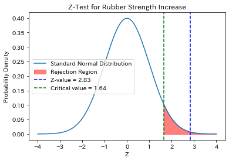

```python
import math
from scipy.stats import norm

# Datos proporcionados
population_mean = 100       # Media de la hipótesis nula
sample_mean = 102           # Media muestral
varianza = 5.0              # Varianza poblacional
n = 10                      # Tamaño de la muestra

sigma = math.sqrt(varianza)
# Cálculo de valor Z
z_value = (sample_mean - population_mean) / (sigma / math.sqrt(n))

# Nivel de significancia (5%)
alpha = 0.05

# Valor crítico de Z (prueba de una cola)
z_critical = norm.ppf(1 - alpha)

# 結果表示
print(f"Estadístico Z: {z_value:.3f}")
print(f"Valor crítico: {z_critical:.3f}")

if z_value > z_critical:
    print("Se puede rechazar la hipótesis nula → Se puede decir que la fuerza ha aumentado.")
else:
    print("No se puede rechazar la hipótesis nula → No se puede decir que la fuerza haya aumentado.")

# 標準正規分布のプロット
x = np.linspace(-4, 4, 1000)
y = stats.norm.pdf(x)

plt.plot(x, y, label='Standard Normal Distribution')
plt.fill_between(x, 0, y, where=(x > z_critical), color='red', alpha=0.5, label='Rejection Region')
plt.axvline(z_value, color='blue', linestyle='--', label=f'Z-value = {z_value:.2f}')
plt.axvline(z_critical, color='green', linestyle='--', label=f'Critical value = {z_critical:.2f}')

plt.title('Z-Test for Rubber Strength Increase')
plt.xlabel('Z')
plt.ylabel('Probability Density')
plt.legend()
plt.show()
```

## 11.2

正規分布に従う母集団 $ N(\mu,\sigma^2) $ からのランダムサンプリング $ \bar{x} $ に基づいて母平均 $ \mu $ の推定を行うとき、その推定には、点推定と区間推定がある。区間推定を行うにあたっては、信頼率を求める。信頼率とは、信頼率によって定められた区間（信頼区間）に統計量 **母数** が存在する確率として設定するものである。母平均の信頼区間は：

1. 信頼率が**小さく**なると、
2. $ \sigma $ が**小さく**なると、
3. サンプルの大きさが**大きく**なると、 **狭く**なる。

El intervalo de confianza por la media poblacional es:

1. Cuando el nivel de confianza **disminuye**,
2. Cuando la desviación estándar $ \sigma $ **disminuye**,
3. Cuando el tamanño de la muestra **anumenta**,

el intervalo se vuelve más **estrecho**.

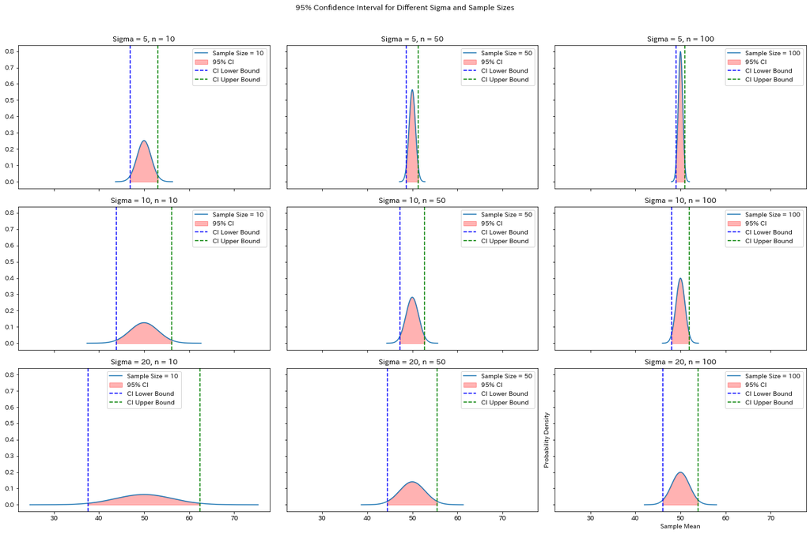

```python
# パラメータの設定
mu = 50  # 母平均
sigma_values = [5, 10, 20]  # 異なる母標準偏差の値
sample_sizes = [10, 50, 100]  # 異なるサンプルサイズの値

# 信頼区間を計算する関数
def confidence_interval(mean, sigma, n, confidence=0.95):
    z = stats.norm.ppf(1 - (1 - confidence) / 2)
    margin_of_error = z * (sigma / np.sqrt(n))
    return (mean - margin_of_error, mean + margin_of_error)

# グラフの設定
fig, axs = plt.subplots(len(sigma_values), len(sample_sizes), figsize=(18, 12), sharex=True, sharey=True)

for i, sigma in enumerate(sigma_values):
    for j, n in enumerate(sample_sizes):
        mean = mu
        lower, upper = confidence_interval(mean, sigma, n)
        x = np.linspace(mean - 4*sigma/np.sqrt(n), mean + 4*sigma/np.sqrt(n), 1000)
        y = stats.norm.pdf(x, loc=mean, scale=sigma/np.sqrt(n))

        axs[i, j].plot(x, y, label=f'Sample Size = {n}')
        axs[i, j].fill_between(x, 0, y, where=(x >= lower) & (x <= upper), color='red', alpha=0.3, label='95% CI')
        axs[i, j].axvline(lower, color='blue', linestyle='--', label=f'CI Lower Bound')
        axs[i, j].axvline(upper, color='green', linestyle='--', label=f'CI Upper Bound')

        axs[i, j].set_title(f'Sigma = {sigma}, n = {n}')
        axs[i, j].legend()

plt.suptitle('95% Confidence Interval for Different Sigma and Sample Sizes')
plt.xlabel('Sample Mean')
plt.ylabel('Probability Density')
plt.tight_layout(rect=[0, 0, 1, 0.96])
plt.show()
```

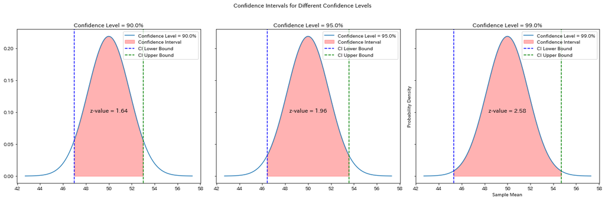

```python
# パラメータの設定
mu = 50  # 母平均
sigma = 10  # 母標準偏差
n = 30  # サンプルサイズ
confidence_levels = [0.90, 0.95, 0.99]  # 信頼率

# 信頼区間を計算する関数
def confidence_interval(mean, sigma, n, confidence):
    z = stats.norm.ppf(1 - (1 - confidence) / 2)
    margin_of_error = z * (sigma / np.sqrt(n))
    return (mean - margin_of_error, mean + margin_of_error), z

# グラフの設定
fig, axs = plt.subplots(1, len(confidence_levels), figsize=(18, 6), sharex=True, sharey=True)

for i, confidence in enumerate(confidence_levels):
    mean = mu
    (lower, upper), z_value = confidence_interval(mean, sigma, n, confidence)
    x = np.linspace(mean - 4*sigma/np.sqrt(n), mean + 4*sigma/np.sqrt(n), 1000)
    y = stats.norm.pdf(x, loc=mean, scale=sigma/np.sqrt(n))

    axs[i].plot(x, y, label=f'Confidence Level = {confidence*100}%')
    axs[i].fill_between(x, 0, y, where=(x >= lower) & (x <= upper), color='red', alpha=0.3, label='Confidence Interval')
    axs[i].axvline(lower, color='blue', linestyle='--', label=f'CI Lower Bound')
    axs[i].axvline(upper, color='green', linestyle='--', label=f'CI Upper Bound')
    axs[i].text(mean, 0.1, f'z-value = {z_value:.2f}', horizontalalignment='center', fontsize=12, color='black')

    axs[i].set_title(f'Confidence Level = {confidence*100}%')
    axs[i].legend()

plt.suptitle('Confidence Intervals for Different Confidence Levels')
plt.xlabel('Sample Mean')
plt.ylabel('Probability Density')
plt.tight_layout(rect=[0, 0, 1, 0.96])
plt.show()
```

## 11.3

あるラインで製造されている樹脂材料の延性の母平均 $ \mu_0 $ は 50、母分散 $ \sigma^2 $ は $ 6^2 $ であった。延性のバラつきの低減を目的に、製造条件の改善を行い $ n = 9 $ の試作品の延性を測定した。 試作品の延性の平均は $ \bar{x} = 51 $、分散は $ V=9 $ であった。改善の効果があったかについて有意水準５％で検定し、信頼率９５％の区間推定を行う。

Este problema es una prueba y estimación de la varianza poblacional de una única población. Es una prueba de una cola diseñada para detectar una disminución en la varianza poblacional.

Paso 1: Establecimiento de la hipótesis nula H0 y la hipótesis alternativa H1

$ H_0 : \sigma^2 = \sigma_0^2 \qquad (\sigma_0^2 = 6^2) $

$ H_1 : \sigma^2 < \sigma_0^2 $

$ \alpha = 0.05$

Paso 2: Establecimiento de la región de rechazo

$ R : \chi_0^2 \le \chi^2 (\phi, 1 - \alpha) = \chi^2 (n-1, 0.95) = 2.73$

Paso 3: Cálculo del estadístico de prueba

$ \chi_0^2 = \frac{S}{\sigma_0^2} = \frac{(n-1)V}{\sigma_0^2} = 2.0 $

Paso 4: Conclusión

$ \chi_0^2 = 2.0 < \chi^2 (8,0.95) = 2.73 $

Es significativo al nivel de significancia del 5%. Es decir, al nivel de significancia del 5%, la hipótesis nula se rechaza, y se puede afirmar que la variabilidad en la ductilidad después de la mejora se ha reducido.

Paso 5: Estimación de varianza poblacional

Estimación puntual

$ \hat{\sigma}^2 = V = \frac{S}{n-1} = 9 $

Estimación por intervalo con un nivel de confianza del 95%

$ \sigma_U^2 = \frac{S}{\chi^2 (8, 0.975)} = 33.0 $

$ \sigma_L^2 = \frac{S}{\chi^2(8, 0.025)} = 4.1 $

```python
from scipy.stats import chi2

# Datos proporcionados
s2 = 9             # Varianza muestral
sigma0_2 = 36      # Varianza pobacional de la hipótesis nula
n = 9              # Tamaño de la muestra
df = n - 1         # Grados de libertad (gl)
alpha = 0.05       # Nivel de significancia

# Paso 2:
# Valor crítico de la distribución ji-cuadrado
chi2_critical = chi2.ppf(alpha, df)

print("Paso 2: Establecimiento de la región de rechazo")
print(f"Valor chi-cuadrado: {chi2_critical:.2f}")


# Paso 3:
# Estadístico de prueba (ji-cuadrado)
chi2_stat = (df * s2) / sigma0_2

print("\nPaso 3: Cálculo del estadístico de prueba")
print(f"valor χ²: {chi2_stat:.2f}")


# Paso 4:
print("\nPaso 4: Conclusión")
print(f"valor χ²: {chi2_stat:.2f} < Valor clítico: {chi2_critical:.2f}")

if chi2_stat < chi2_critical:
    print("Se rechaza la hipótesis nula → La dispersión ha disminuido (hay un efecto de mejora) ")
else:
    print("No se puede rechazar la hipótesis nula → No se puede decir que la dispersión haya disminuido.")

# Paso 5
print("\nPaso 5: Estimación de varianza poblacional ")
print(f"Estimacion Puntual: {s2}")

# Intervalo de confianza (intervalo de confianza del 95% para la varianza poblacional)
chi2_lower = chi2.ppf(alpha / 2, df)
chi2_upper = chi2.ppf(1 - alpha / 2, df)

lower = (df * s2) / chi2_upper
upper = (df * s2) / chi2_lower

print(f"Intervalo de confianza del 95%: ({lower:.1f}, {upper:.1f})")
```

```
Paso 2: Establecimiento de la región de rechazo
Valor chi-cuadrado: 2.73

Paso 3: Cálculo del estadístico de prueba
valor χ²: 2.00

Paso 4: Conclusión
valor χ²: 2.00 < Valor clítico: 2.73
Se rechaza la hipótesis nula → La dispersión ha disminuido (hay un efecto de mejora)

Paso 5: Estimación de varianza poblacional
Estimacion Puntual: 9
Intervalo de confianza del 95%: (4.1, 33.0)
```

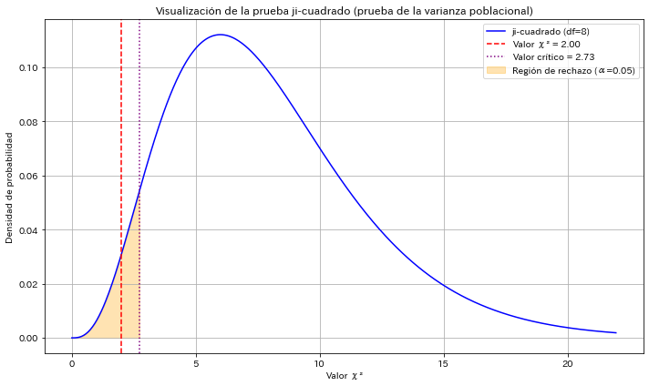

```python
# --- グラフ描画 ---
x = np.linspace(0.01, chi2.ppf(0.995, df), 500)
y = chi2.pdf(x, df)

plt.figure(figsize=(10, 6))
plt.plot(x, y, 'b-', label='ji-cuadrado (df=8)')

# χ²値
plt.axvline(chi2_stat, color='red', linestyle='--', label=f'Valor χ² = {chi2_stat:.2f}')
# Valor crítico（región de rechazo）
plt.axvline(chi2_critical, color='purple', linestyle=':', label=f'Valor crítico = {chi2_critical:.2f}')

# 塗りつぶし（棄却域）
x_fill = np.linspace(0, chi2_critical, 200)
plt.fill_between(x_fill, chi2.pdf(x_fill, df), color='orange', alpha=0.3, label='Región de rechazo (α=0.05)')

plt.title('Visualización de la prueba ji-cuadrado (prueba de la varianza poblacional)')
plt.xlabel('Valor χ²')
plt.ylabel('Densidad de probabilidad')
plt.legend()
plt.grid(True)
plt.tight_layout()
plt.show()
```

## 11.4

あるラインで製造されている金属材料の強度の母平均、$ \mu_0 = 50 $、母分散 $ \sigma_0^2 = 6^2 $ であった。強度の母平均の向上を目的に、製造条件の改善をおこない $ n=9 $ の試作品の強度を測定した。 試作品の強度の平均は $ \bar{x} = 54 $ であった。改善の延性のバラつきは変わらないもとのして、改善の効果があったかどうか有意水準５％で検定する。

En una línea de producción, la media poblacional de la resistencia de un material metálico era $ \mu_0 = 50 $, y la varianza poblacional era $ \sigma_0^2 = 6^2 $. Con el objetivo de mejorar la media poblacional de la resistencia, se realizaron mejoras en las condiciones de producción y se midió la resistencia de una mustra de $ n=9 $ prototipos.

La media de la resistencia de los prototipos fue $ \bar{x} = 54 $. Asumiendo que la dispersión de la resistencia no cambió con la mejora, realiza una prueba de hipóteis con un nivel de significancia del 5% para determinar si hubo un efecto de la mejora.

Este problema es una prueba sobre la media poblacional de una única población. La varianza poblacional es conocida, y es una prueba de una cola para determinar si la media poblacional ha aumentado.

Paso 1:

$ H_0 : \mu = \mu_0 \qquad (\mu_0 = 50) $

$ H_1 : \mu > \mu_0 $

$ \alpha = 0.05 $

Paso 2:

$ R : u_0 \ge u(2\alpha) = u(0.10) = 1.645 $

Paso 3:

$ u_0 = (\bar{x} - \mu_0) / \sqrt{\sigma_0^2 / n} $ = 2.0

Paso 4:

$ u_0 = 2.0 > u(0.10) = 1.645 $

Es significativo al nivel de significancia del 5%.

Es decir, al nivel de significancia del 5%, la hipótesis nula se rechaza, y se puede afirmar que la media poblacional de la resistencia después de la mejora ha aumentado.

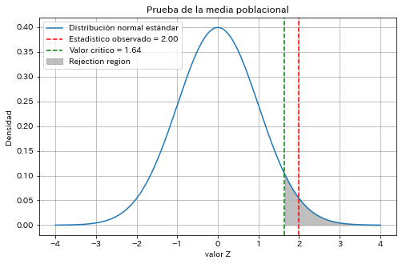

```
Valor del estadístico de prueba: 2.00
Valor crítico de la región de rechazo: 1.645
Conclusión: la hipótesis nula es rechazada
```

```python
from scipy.stats import norm

# 元のデータ
mu_0 = 50
sigma_0 = np.sqrt(36)
n = 9

# 改善後の試作品データ
xbar = 54

# 有意水準
alpha = 0.05

# 検定統計量の計算
z = (xbar - mu_0) / (sigma_0 / np.sqrt(n))

# 棄却域の計算
z_critical = norm.ppf(1 - alpha)

# 結論
reject_H0 = z > z_critical

# グラフの作成
x = np.linspace(-4, 4, 400)
z_dist = norm.pdf(x, 0, 1)

plt.figure(figsize=(8, 5))
plt.plot(x, z_dist, label='Distribución normal estándar')
plt.axvline(z, color='r', linestyle='--', label=f'Estadistico observado = {z:.2f}')
plt.axvline(z_critical, color='g', linestyle='--', label=f'Valor critico = {z_critical:.2f}')
plt.fill_between(x, 0, z_dist, where=(x > z_critical), color='gray', alpha=0.5, label='Rejection region')
plt.title('Prueba de la media poblacional')
plt.xlabel('valor Z')
plt.ylabel('Densidad')
plt.legend()
plt.grid(True)
plt.show()

print(f"Valor del estadístico de prueba: {z:.2f}")
print(f"Valor crítico de la región de rechazo: {z_critical:.3f}")
print("Conclusión: la hipótesis nula " + ("es rechazada" if reject_H0 else "no es rechazada"))
```

## 11.5

あるラインで製造されている磁性材料の密度の母平均 $ \mu_0 = 50 $、母分散 $ \sigma_0^2 = 6^2 $ であった。密度の向上を目標に、製造条件の改善をおこない $ n=9 $ の試作品の密度を測定した。

試作品の密度の平均は $ \bar{x} = 54 $, 分散は $ V = 9 $ であった。完全後の密度のバラつきはかわらないもののとして、改善の効果があったかどうか有意すいじゅん５％で検定し、信頼率９５％の区間推定を行う。

En una línea de producción, la media poblacional de la densidad de un material magnético era $ \mu_0 = 50 $, y la varianza poblacional era $ \sigma_0^2 = 6^2 $. Con el objetivo de mejorar la densidad, se realizaron mejoras en las condiciones de producción y se midió la densidad de una muestra de $ n=9 $ prototipos.

La media de la densidad de los prototipos fue $ \bar{x} = 54 $, y la varianza fue $ V = 9 $. Asumiendo que la dispersión de la densidad después de la mejora no cambió, realiza una prueba de hipótesis con un nivel de significancia del 5% para determinar si hubo un efecto de la mejora, y calcula un intervalo de confianza del 95% para la media.

Este problema es una prueba y estimación de la media poblacional de una única población.

La varianza poblacional es desconocida, y es una prueba de una cola para determinar si la media poblacional ha aumentado.

Paso 1:

$ H_0 : \mu = \mu_0 \qquad (\mu_0 = 50) $

$ H_1 : \mu > \mu_0 $

$ \alpha = 0.05 $

Paso 2:

$ R : t_0 \ge t(\phi ,2\alpha) = t(n-1, 0.10) = t(8,0.10) = 1.860 $

Paso 3:

$ t_0 = ( \bar{x} - \mu_0 ) / \sqrt{V/n} = 4.0 $

Paso 4:

$ t_0 = 4.0 > t(8,0.10)=1.860 $

Es significativo al nivel de significancia del 5%. Es decir, al nivel de significancia del 5%, la hipótesis nula se rechaza, y se puede afirmar que la media poblacional de la densidad después de la mejora ha aumentado.

Paso 5:

$ \bar{x} \pm t(\phi, 0.05)\sqrt{V/n} = 54 \pm 2.306 $

```
Estadistico t: 4.00
Valor critico t: 1.86
La hipótesis nula es rechazada, se considera que hubo un efecto de mejora
Intervalo de confianza（95%）: [51.7 56.3]
P value 0.0039
```

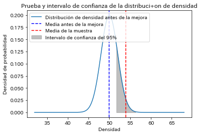

```python
# データの定義
mu_0 = 50      # 改善前の母平均
sigma_0 = np.sqrt(36)  # 改善前の母標準偏差
n = 9         # サンプルサイズ
x_bar = 54    # サンプル平均
s = np.sqrt(9)  # サンプル標準偏差
alpha = 0.05  # 有意水準

# t検定の実行
t_stat = (x_bar - mu_0) / (s / np.sqrt(n))
t_critical = stats.t.ppf(1 - alpha, df=n-1)

# 結果の表示
print(f"Estadistico t: {t_stat:.2f}")
print(f"Valor critico t: {t_critical:.2f}")

if t_stat > t_critical:
    print("La hipótesis nula es rechazada, se considera que hubo un efecto de mejora")
else:
    print("La hipótesis nula no es rechazada, se considera que no hubo efecto que no hubo efecto de mejora")

# 信頼区間の計算
confidence_level = 0.95
t_value = stats.t.ppf((1 + confidence_level) / 2, df=n-1)
margin_of_error = t_value * (s / np.sqrt(n))
confidence_interval = (x_bar - margin_of_error, x_bar + margin_of_error)
confidence_interval = np.round(confidence_interval,1)
print(f"Intervalo de confianza（95%）: {confidence_interval}")

# t検定の統計量の計算
t_statistic = (x_bar - mu_0) / (s / np.sqrt(n))

# 自由度
df = n - 1

# p値の計算（両側検定）
p_value = 2 * (1 - stats.t.cdf(abs(t_statistic), df))
print(f"P value {p_value:.4f}")

# グラフの作成
x = np.linspace(mu_0 - 3*sigma_0, mu_0 + 3*sigma_0, 1000)
y = stats.norm.pdf(x, mu_0, sigma_0/np.sqrt(n))

plt.plot(x, y, label="Distribución de densidad antes de la mejora")
plt.axvline(x=mu_0, color='blue', linestyle='--', label="Media antes de la mejora")
plt.axvline(x=x_bar, color='red', linestyle='--', label="Media de la muestra")
plt.fill_between(x, 0, y, where=(x > confidence_interval[0]) & (x < confidence_interval[1]), color='gray', alpha=0.5, label="Intervalo de confianza del 95%")

plt.title("Prueba y intervalo de confianza de la distribuci+on de densidad")
plt.xlabel("Densidad")
plt.ylabel("Densidad de probabilidad")
plt.legend(loc='upper left')
plt.show()
```

## 11.6-1

二つのラインA、Bで製造される鋼線の強度の母平均は $ \mu_A $、$ \mu_B $ である。また、母分散は不明であるが、同程度の値であることが分かっている。二つのラインの鋼線の強度に差がないかどうかを検討したい。

En dos líneas de producción, A y B, la media población de la resistencia del alambre de acero es $ \mu_A $ y $ \mu_B $ respectivamente. Se sabe que las varianzas poblacionales son desconocidas, pero de valores similares. Se desea investigar si existe una diferencia en la resistencia del alambre de acero entre las dos líneas.

Es una prueba de dos colas sobre la diferencia entre las medias poblacionales de dos poblaciones.

Es el caso en que las varianza pobalacionales son desconocidas, pero se consideran iguales ($ \sigma_A^2 = \sigma_B^2 $)

Hipótesis nula:

- $ H_0 : \mu_A = \mu_B $

Hipótesis alternativa:

- $ H_1 : \mu_A \neq \mu_B $

Estadístico de prueba:

- $ t_0 = \frac{\bar{x}_A -\bar{x}_B}{\sqrt{V(\frac{1}{n_A} + \frac{1}{n_B})}} $ ただし $ V = \frac{S_A + S_B}{n_A + n_B -2} $

```
t-statistic: 1.2725698166200137, p-value: 0.20824865119076585
```

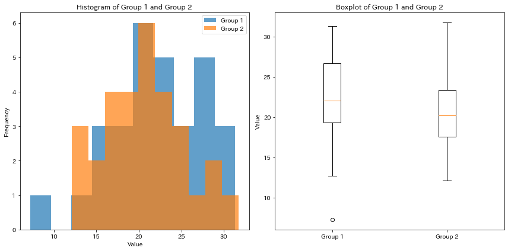

```python
# データ生成
np.random.seed(0)
mu1, sigma1, n1 = 20, 5, 30  # グループ1の平均、標準偏差、サンプル数
mu2, sigma2, n2 = 22, 5, 30  # グループ2の平均、標準偏差、サンプル数

group1 = np.random.normal(mu1, sigma1, n1)
group2 = np.random.normal(mu2, sigma2, n2)

df = pd.DataFrame({'Group 1': group1, 'Group 2': group2})
df.to_excel('Data2/11_6-1.xlsx')

# 独立二標本t検定
t_stat, p_value = stats.ttest_ind(group1, group2, equal_var=True)
print(f't-statistic: {t_stat}, p-value: {p_value}')

# グラフの描画
plt.figure(figsize=(12, 6))

# ヒストグラム
plt.subplot(1, 2, 1)
plt.hist(group1, bins=10, alpha=0.7, label='Group 1')
plt.hist(group2, bins=10, alpha=0.7, label='Group 2')
plt.legend(loc='upper right')
plt.title('Histogram of Group 1 and Group 2')
plt.xlabel('Value')
plt.ylabel('Frequency')

# 箱ひげ図
plt.subplot(1, 2, 2)
plt.boxplot([group1, group2], labels=['Group 1', 'Group 2'])
plt.title('Boxplot of Group 1 and Group 2')
plt.ylabel('Value')

plt.tight_layout()
plt.show()
```

## 11.6-2

金属中のガス成分を２つの方法で測定している。１０ロットのサンプルについてそれぞれを２分し２つの分析方法（A法、B法）で分析を行った。２つの方法による測定値の母平均MA,MBに差がないかどうか検定したい。

Se están midiendo los componentes de gas en un metal mediante dos métodos. Diez muestras de lote se dividieron, y cada mitad fue analizada utilizando los dos métodos de análisis (Método A, Método B). Queremos probar si hay una diferencia entre las medias poblaciones ($ \mu_A $ y $ \mu_B $) de los valores mediados por los dos métodos.

Aunque parece que el estudio involucra a dos poblaciones, cada una de las mediciones se ve afectada por el lote común, lo que resulta en datos pareados (o dependientes). En este caso, el análisis se realiza tomando la diferencia entre los datos $ d_i = x_{Ai} - x_{Bi} $ y asumiendo que esa diferencia proviene de una población $ N ((\mu_A - \mu_B), \sigma_d^2) $. Por lo tanto, el análisis se puede llevar a cabo de la misma manera que una prueba de dos colas sobre la media poblacional de una única población. Se asume que la varianza pobalacional es desconocida.

対応のあるデータの場合

Hipótesis nula:

- $ H_0 : \mu_A = \mu_B $

Hipótesis alternativa:

- $ H_1 : \mu_A \neq \mu_B $

Estadístico de prueba:

- $ t_0 = \frac{\bar{d}}{\sqrt{V_d / n}} $

```
t-statistic: -1.7848794771059635, p-value: 0.10794104681485403
```

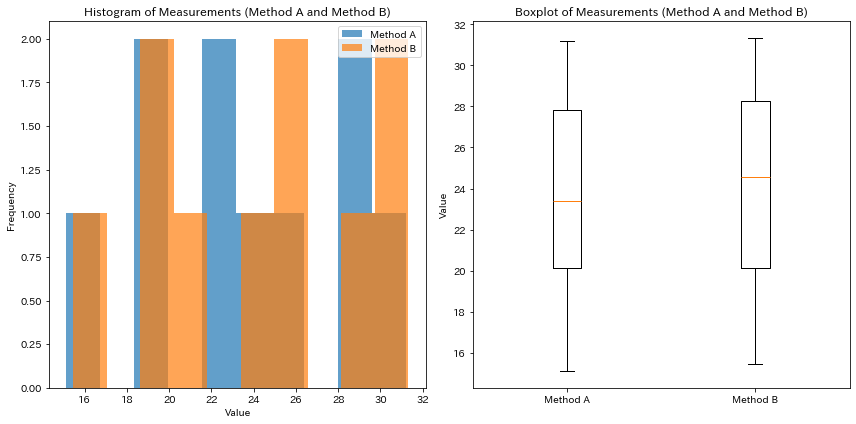

```python
# データ生成
np.random.seed(0)
# 10ロットのサンプルデータ
sample_size = 10
# A法の測定値（例としてランダムなデータを生成）
measurements_A = np.random.normal(20, 5, sample_size)
# B法の測定値（例としてA法に対して少しずらしたデータを生成）
measurements_B = measurements_A + np.random.normal(0, 1, sample_size)

df = pd.DataFrame({'A': measurements_A, 'B': measurements_B})
df.to_excel('Data2/11_6-2.xlsx')

# 対応のあるt検定
t_stat, p_value = stats.ttest_rel(measurements_A, measurements_B)
print(f't-statistic: {t_stat}, p-value: {p_value}')

# グラフの描画
plt.figure(figsize=(12, 6))

# ヒストグラム
plt.subplot(1, 2, 1)
plt.hist(measurements_A, bins=10, alpha=0.7, label='Method A')
plt.hist(measurements_B, bins=10, alpha=0.7, label='Method B')
plt.legend(loc='upper right')
plt.title('Histogram of Measurements (Method A and Method B)')
plt.xlabel('Value')
plt.ylabel('Frequency')

# 箱ひげ図
plt.subplot(1, 2, 2)
plt.boxplot([measurements_A, measurements_B], labels=['Method A', 'Method B'])
plt.title('Boxplot of Measurements (Method A and Method B)')
plt.ylabel('Value')

plt.tight_layout()
plt.show()
```

```python
import gspread
from gspread_dataframe import set_with_dataframe
from oauth2client.service_account import ServiceAccountCredentials

# スプレッドシートを開く（URLまたはスプレッドシートIDを使用）
SPREADSHEET_ID = "1a_qscrI6712-9-6XhA1bc5rURnvaeXKKpuXhO8grv6c"
sheet = client.open_by_key(SPREADSHEET_ID).worksheet("Sheet1") # 最初のシートを取得

# データを取得
list_of_lists = sheet.get_all_records()
df = pd.DataFrame(list_of_lists)

# インデックスをリセット
df.reset_index(drop=True, inplace=True)

# 数値に変換する関数
def convert_to_numeric(df):
    for col in df.columns:
        df[col] = pd.to_numeric(df[col], errors='coerce')
    return df

df = convert_to_numeric(df)
df = df.drop(df.columns[0], axis=1)

# 対応のあるt検定
t_stat, p_value = stats.ttest_ind(df['Group 1'], df['Group 2'])
print(f't-statistic: {t_stat:.3f}, p-value: {p_value:.3f}')
```

```
t-statistic: 1.273, p-value: 0.208
```

## 11.7-1

あるラインで製造される機械部品の従来の不適合品率は $ P_0 = 5.0% $ であった。今回、製造設備の更新を行い、試作品（ $ n = 400 $ 個）の機械部品を検査したところ、部適合品は $ x=12 $ であった。不適合品率 $ P $ が変わったかどうかを検討する。

La tasa de articulos no **conformes** de piezas mecánicos producidas en una línea era del $ P_0 = 5.0% $. Después de actualizar el equipo de producción, se inspeccionó una muestra de $ n = 400 $ piezas mecánicas de prototipos, encontrándose $ x=12 $ artículos no conformes. Se desea investigar si la tasa de artículos no conformes $ P $ ha cambiado.

Es una prueba de dos colas sobre la proporción de no conformidades (o defectuosos) de una única población, donde se quiere probar si la proporción de no conformidades ha cambiado.

Paso 1:

$ H_0 : P = P_0 $ ただし、 $ (P_0 = 0.050) $

$ H_1 : P \neq P_0 $

$ \alpha = 0.05 $

Paso 2: Análisis de las condiciones para la aproximación a la distribución normal.

$ nP_0 = 20 > 5 $

$ n(1 - p_0) = 380 > 5 $

Paso 3:

$ R: |u_0| \geq u(\alpha) = u(0.05) = 1.960 $

Paso 4:

$ p = x/n = 0.030 $

$ u_0 = (p - P_0)/\sqrt{P_0(1-P_0)/n} = -1.835 $

Paso 5:

$ |u_0| = 1.835 < u(0.05) = 1.960 $

Por lo tanto, no es significativo. Es decir, al nivel de significancia del 5%, no se puede afirmar que la proporción de no conformidades (o defectuosos ) haya cambiado.

```python
# Tasa de defectos anterior
p_old = 0.05  # Número de muestras probadas
n = 400       # Número de muestras probadas
x_new = 12    # Número de defectos

alpha = 0.05

# Paso 2:
print("Paso 2:")
print(f" nP0 = {n} x {p_old} = {n*p_old} > 5")
print(f" n(1-P0) = {n} x {(1-p_old)} = {n*(1-p_old)} > 5")

# Paso 3:
# Cálculo del área de rechazo
z_critical = stats.norm.ppf(1-alpha/2)

print("\nPaso 3:")
print(f"R: u(0.05) = {z_critical:.3f}")

# Paso 4:
# Tasa de defectos del prototipo
p_new = x_new / n

# Cálculo del error estándar
standard_error = (p_old * (1 - p_old) / n) ** 0.5

# Cálculo del puntaje Z
z_score = (p_new - p_old) / standard_error

print("\nPaso 4:")
print(f"u0: {z_score:.4f}")

# Paso 5:
# Cálculo del valor P de la prueba bilateral
p_value = 2 * (1 - stats.norm.cdf(abs(z_score)))

print("\nPaso 5:")
print(f"u0 = {z_score:.3f} < u(0.05) = {z_critical:.3f}")

if p_value < alpha:
    print("\nRechazo la hipótesis nula. La nueva tasa de defectos es diferente a la tasa de defectos anterior.")
else:
    print("\nNo rechazo la hipótesis nula. No hay diferencia entre la nueva tasa de defectos y la tasa de defectos anterior.")
```

```
Paso 2:
 nP0 = 400 x 0.05 = 20.0 > 5
 n(1-P0) = 400 x 0.95 = 380.0 > 5

Paso 3:
R: u(0.05) = 1.960

Paso 4:
u0: -1.8353

Paso 5:
u0 = -1.835 < u(0.05) = 1.960

No rechazo la hipótesis nula. No hay diferencia entre la nueva tasa de defectos y la tasa de defectos anterior.
```

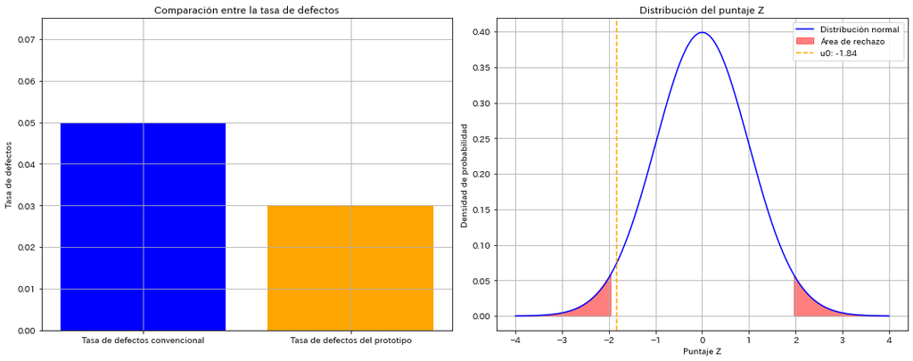

```python
# Creación de gráfico de barras
labels = ['Tasa de defectos convencional', 'Tasa de defectos del prototipo']
rates = [p_old, p_new]

plt.figure(figsize=(15, 6))

plt.subplot(1, 2, 1)
plt.bar(labels, rates, color=['blue', 'orange'])
plt.ylim(0, max(rates) * 1.5)
plt.ylabel('Tasa de defectos')
plt.title('Comparación entre la tasa de defectos')
plt.grid(True)

# Creación de la distribución del puntaje Z
x = np.linspace(-4, 4, 1000)
y = stats.norm.pdf(x)

plt.subplot(1, 2, 2)
plt.plot(x, y, label='Distribución normal', color='blue')
plt.fill_between(x, y, where=(x > abs(z_critical)), color='red', alpha=0.5, label='Área de rechazo')
plt.fill_between(x, y, where=(x < -abs(z_critical)), color='red', alpha=0.5)
plt.axvline(z_score, color='orange', linestyle='--', label=f'u0: {z_score:.2f}')
plt.title('Distribución del puntaje Z')
plt.xlabel('Puntaje Z')
plt.ylabel('Densidad de probabilidad')
plt.legend()
plt.tight_layout()
plt.grid(True)
plt.show()
```

## 11.7-2

二つのライン（A、B）で製造される機械部品がある。各ラインからそれぞれ $ n_A = n_B = 1000 $ 個のサンプルを抜き取って検査したところ、Aラインでは $ x_A = 15 $ 個、Bラインでは $ x_B =25 $ 個の不適合があった。ラインによって母不適合品率 $ P_A $、$ P_B $ に違いがあるかどうかを検討する。

Se producen piezas mecánicas en dos líneas (A y B). Se extrajo una muestra de $ n_A = n_B = 1000 $ piezas de cada línea para su inspección, encontorándose $ x_A = 15 $ articulos no conformes en la línea A y $ x_B =25 $ artículos no conformes en la línea B. Se desea investigar si existe una diferencia en las tasas de artículos no conformes poblacionales $ P_A $、$ P_B $ entre las líneas.

Es una prueba de dos colas sobre la diferencia entre las proporciones de no conformidades (o defectuosos) de dos poblaciones, donde se quiere probar si existe una diferencia en las proporciones.

Paos 1:

$ H_0 : P_A = P_B $

$ H_1 : P_A \neq P_B $

$ \alpha = 0.05 $

Paso 2: Análisis de las condiciones para la aproximación a la distribución normal.

$ x_A = 15 > 5, \qquad n_A - x_A = 1000 -15 = 985 > 5 $

$ x_B = 25 > 5, \qquad n_B - x_B = 1000 -25 = 975 > 5 $

Paso 3:

$ R: |u_0| \geq u(\alpha) = u(0.05) = 1.960 $

Paso 4:

$ P_A = x_A / n_A = 0.0150, \qquad P_B = x_B / n_B = 0.0250 $

$ \bar{P} = (x_A + x_B) / (n_A + n_B) = 0.020 $

$ u_0 = (P_A - P_B)/\sqrt{\bar{P}(1-\bar{P})(1/n_A + 1/n_B)} = -1.597 $

Paso 5:

$ |u_0| = 1.597 < u(0.05)=1.960 $

Por lo tanto, no es significativo. Es decir, al nivel de significancia del 5%, no se puede afirmar que haya una diferencia en las proporciones de no conformidades (o defectuosos).

```python
import numpy as np
import matplotlib.pyplot as plt
from scipy.stats import norm

# Tamaño de muestra
n_A = 1000
n_B = 1000

# Número de defectuosos
fail_A = 15
fail_B = 25

# Paso 1:
alpha = 0.05

# Paso 2:
print("Paso 2:")
print(f"x_A = {fail_A} > 5, n_A - x_A = {n_A - fail_A} > 5")
print(f"x_B = {fail_B} > 5, n_B - x_B = {n_B - fail_B} > 5")

# Tasa de defectos
p_A = fail_A / n_A
p_B = fail_B / n_B

# Paso 3:
# Cálculo del área de rechazo
z_critical = stats.norm.ppf(1-alpha/2)

print("\nPaso 3:")
print(f"R: u(0.05) = {z_critical:.3f}")

# Tasa de defecctos total
p_pooled = (fail_A + fail_B) / (n_A + n_B)


# Paso 4:
# Error estándar
se = np.sqrt(p_pooled * (1 - p_pooled) * (1 / n_A + 1 / n_B))

# Valor u0
z = (p_A - p_B) / se

print(f"\nPaso 4:")
print(f"u0: {z:.3f}")


# Paso 5:

# Valor p
p_value = 2 * (1 - norm.cdf(abs(z)))


# Cáluculo del área de rechazo
z_critical = stats.norm.ppf(1-alpha/2)

print("\nPaso 5:")
print(f"u0 = {abs(z):.3f} < u(0.05) = {z_critical:.3f}")

if -z > z_critical:
    print( "\nRechazo la hipótesis nula. La nueva tasa de defectos es diferente e la tasa de defectos anterior.")
else:
    print( "\nNo rechazo la hipótesis nula. No hay diferencia entre la nueva tasa de defectos y la tasa de defectos anterior.")
```

```
Paso 2:
x_A = 15 > 5, n_A - x_A = 985 > 5
x_B = 25 > 5, n_B - x_B = 975 > 5

Paso 3:
R: u(0.05) = 1.960

Paso 4:
u0: -1.597

Paso 5:
u0 = 1.597 < u(0.05) = 1.960

No rechazo la hipótesis nula. No hay diferencia entre la nueva tasa de defectos y la tasa de defectos anterior.
```

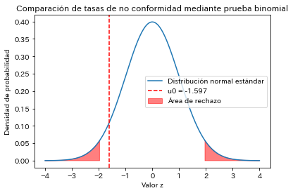

```python
# Creación de gráfico
x = np.linspace(-4, 4, 1000)
y = norm.pdf(x, 0, 1)

plt.plot(x, y, label="Distribución normal estándar")
plt.axvline(z, color='r', linestyle='--', label=f"u0 = {z:.3f}")
plt.fill_between(x, 0, y, where=(x < -abs(z_critical)) | (x > abs(z_critical)), color='red', alpha=0.5, label="Área de rechazo")

plt.title('Comparación de tasas de no conformidad mediante prueba binomial')
plt.xlabel('Valor z')
plt.ylabel('Densidad de probabilidad')
plt.legend()
plt.show()
```

## 11.7-3

あるメーカーで製造される帯状繊維には、従来１㎡あたり平均 $ \lambda_0 = 2 $ 個の傷があった。今回、製造ラインの改善を行い、試作品から $ n = 10 m^2 $ の繊維を検査したところ合計 $ T = 9 $ の傷が見られた。母不適合数が減少したかどうかを検討する。

En una fábrica, la fibra en banda producida tradicionalmente tenía un promedio de $ \lambda_0 = 2 $ defectos por metro cuadrado. Después de realizar mejoras en la línea de producción, se inspeccionaron $ n = 10 m^2 $ de fibra de prototipos, encontrándose un total de $ T = 9 $ defectos. Se desea investigar si el número promedio de defectos por metro cuadrado ha disminuido.

Es una prueba de una cola sobre el número de no conformidades (o defectuosos) de una única población, donde se quiere probar si el número de no conformidades ha disminuido.

Paso 1:

$ H_0 : \lambda = \lambda_0 \qquad (\lambda_0 = 2.0) $

$ H_1 : \lambda < \lambda_0 $

$ \alpha = 0.05 $

Paso 2: Análisis de las condiciones para la aproximación a la distribución normal.

$ n \lambda_0 = 10 \times 2.0 = 20.0 > 5 $

Paso 3:

$ R: u_0 \leq -u(2 \alpha) = -u(0.10) = -1.645 $

Paso 4:

$ \hat{\lambda} = T/n = 0.90 $

$ u_0 = (\hat{\lambda} - \lambda_0)/\sqrt{\lambda_0/n} = -2.460 $

Paso 5:

$ u_0 = -2.460 < -u(0.10) = -1.645 $

Por lo tanto, es significativo. Es decir, al nivel de significancia del 5%, se puede afirmar que el número de no conformidades (o defectuosos) poblacional ha disminuido.

```
Número de defectos observados: 9
Media de la hipótesis nula: 20
Rechazar si es menor o igual a : 13  se rechaza la hipótesis nula（α = 0.05)
Valor p: 0.0050
Se rechaza la hipótesis nula → El número de defectos disminuyó significativamente (hay mejora)
```

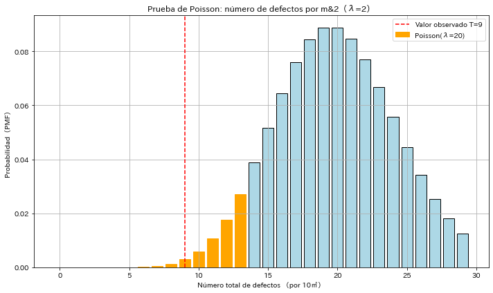

```python
from scipy.stats import poisson

# Parámetoro
lambda0 = 2        # Tasa de ocurrencia de defectos tradicional （defectos/m^2）
n = 10             # Área investigada（m^2）
T = 9              # Número de defectos observados
alpha = 0.05       # Nivel de significancia

# Distribución de Poisson bajo la hipótesis nula（media λ0 * n）
mu0 = lambda0 * n

# Valor p（prueba de cola izquierda：P(T <= 9)）
p_value = poisson.cdf(T, mu0)

# Valor crítico （nivel de significancia del 5%）
critical_value = poisson.ppf(alpha, mu0)

# 結果出力
print(f"Número de defectos observados: {T}")
print(f"Media de la hipótesis nula: {mu0}")
print(f"Rechazar si es menor o igual a : {int(critical_value)}  se rechaza la hipótesis nula（α = 0.05)")
print(f"Valor p: {p_value:.4f}")

if T <= critical_value:
    print("Se rechaza la hipótesis nula → El número de defectos disminuyó significativamente (hay mejora)")
else:
    print("No se puede rechazar la hipótesis nula → No se obersa una disminución significativa en el número de defectos")

# --- グラフ描画 ---
x = np.arange(0, int(mu0 + 10))
pmf = poisson.pmf(x, mu0)

plt.figure(figsize=(10, 6))
bars = plt.bar(x, pmf, color='lightblue', edgecolor='black', label='Poisson(λ=20)')

# 塗りつぶし（棄却域）
for i in range(0, int(critical_value) + 1):
    bars[i].set_color('orange')

# 観測値の位置に線を引く
plt.axvline(T, color='red', linestyle='--', label=f'Valor observado T={T}')

plt.title('Prueba de Poisson: número de defectos por m&2（λ=2）')
plt.xlabel('Número total de defectos （por 10㎡）')
plt.ylabel('Probabilidad（PMF）')
plt.legend()
plt.grid(True)
plt.tight_layout()
plt.show()
```

## 11.7-4

二つの同規模の装置組み立て工場がある。C工場では、最近 $ n_C = 10 $ か月間にライン休止事故が $ T_C = 8 $ 件、D工場では、最近 $ n_D = 10 $ か月にライン休止事故が $ T_D =12 $ 件あった。工場によってライン休止事故件数、$ \lambda_C, \lambda_D $ に違いがあるかどうかを検証する。

Existe dos fábricas de ensamblaje de equipos de tamaño similar, C y D. En la fábrica C, se registraron $ T_C = 8 $ incidentes de paro de líniea en los últimos $ n_C = 10 $ meses, mientras que en la fábrica D, hubo $ T_D =12 $ incidentes de paro de línea en los últimos $ n_D = 10 $ meses. Se desea verificar si existe una diferencia en el número de incidentes de paro de línea, $ \lambda_C, \lambda_D $, entre las fábricas.

$ H_0 : \lambda_C = \lambda_D $

$ H_1 : \lambda_C \neq \lambda_D $

$ \alpha = 0.05 $

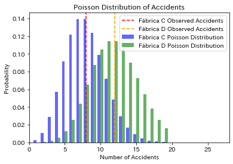

```
Tasa de accidentes mensual en la fábrica C: 0.8
Tasa de accidentes mensual en la fábrica D: 1.2
Número de accidentes observados en la fábrica C: 8
Número de accidentes observados en la fábrica D: 12
Valor p de la prueba de chi-cuadrado: 1.0
No hay una diferencia estadísticamente significativa en el número de accidentes entre la fábrica C y la fábrica D.
```

```python
from scipy.stats import poisson, chi2_contingency

# Parámetros definidos
accidents_C = 8  # Número de accidentes en la fábrica C
accidents_D = 12  # Número de accidentes en la fábrica D
months = 10  # Periodo de observación (10 meses)

# Tasa de accidentes mensual
rate_C = accidents_C / months
rate_D = accidents_D / months

# Calcular el valor esperado
expected_accidents_C = rate_C * months
expected_accidents_D = rate_D * months

# Lista de valores observados y esperados
observed = np.array([accidents_C, accidents_D])
expected = np.array([expected_accidents_C, expected_accidents_D])

# Prueba de chi-cuadrado
chi2, p_value, dof, ex = chi2_contingency([observed, expected])

# Creación de gráficos
x = np.arange(0, 20, 1)
y_C = poisson.pmf(x, expected_accidents_C)
y_D = poisson.pmf(x, expected_accidents_D)

plt.bar(x - 0.2, y_C, width=0.4, alpha=0.6, color='b', label='Fábrica C Poisson Distribution')
plt.bar(x + 0.2, y_D, width=0.4, alpha=0.6, color='g', label='Fábrica D Poisson Distribution')
plt.axvline(x=accidents_C, color='r', linestyle='--', label='Fábrica C Observed Accidents')
plt.axvline(x=accidents_D, color='orange', linestyle='--', label='Fábrica D Observed Accidents')
plt.xlim(0,28)
plt.title('Poisson Distribution of Accidents')
plt.xlabel('Number of Accidents')
plt.ylabel('Probability')
plt.legend()
plt.show()

# 結果の表示
print(f"Tasa de accidentes mensual en la fábrica C: {rate_C}")
print(f"Tasa de accidentes mensual en la fábrica D: {rate_D}")
print(f"Número de accidentes observados en la fábrica C: {accidents_C}")
print(f"Número de accidentes observados en la fábrica D: {accidents_D}")
print(f"Valor p de la prueba de chi-cuadrado: {p_value}")

if p_value < 0.05:
    print("Hay una diferencia estadísticamente significativa en el número de accidentes entre la fábrica C y la fábrica D.")
else:
    print("No hay una diferencia estadísticamente significativa en el número de accidentes entre la fábrica C y la fábrica D.")
```

## 11.8

A、B、Cの三つの工場で製造される同仕様の特殊プラスチックについて調査したところ、表１１．１の結果を得た。工場によって適合品・不適合品の出方に違いがあるかどうか検討する。

Se investigó un plástico especial de las mismas especificaciones fabricado en ters fábricas: A, B y C, obteniéndose los resultados de la Tabla 11.1. Se desea dterminar si existe una diferencia en la proporción de artículos conformes y no conformes según la fábrica.

```python
import numpy as np
from scipy.stats import chi2_contingency

# Datos de la tabla de contingencia
observed = np.array([[160, 40],
                     [170, 30],
                     [150, 50]])


# Cálculo de la frecuencia esperada
row_totals = observed.sum(axis=1)
col_totals = observed.sum(axis=0)
total = observed.sum()

expected = np.outer(row_totals, col_totals) / total

# Estadístico chi-cuadrado、Valor p、Grados de libertad、Cálculo de la frecuencia esperada
chi2_stat, p_val, dof, expected = chi2_contingency(observed)

# Mostrar resultados
print("Tabla de contingencia:")
print(observed)
print("\nFrecuencias esperadas:")
print(expected)
print(f"\nEstadístico Chi-cuadrado: {chi2_stat:.2f}")
print(f"Valor p: {p_val:.4f}")
print(f"Grados de libertad: {dof}")

#  Juicio estadístico usando el valor p
alpha = 0.05
if p_val < alpha:
    print("\nHay una diferencia estadísticamente significativa.")
else:
    print("\nNo hay una diferencia estadísticamente significativa")
```

```
Tabla de contingencia:
[[160  40]
 [170  30]
 [150  50]]

Frecuencias esperadas:
[[160.  40.]
 [160.  40.]
 [160.  40.]]

Estadístico Chi-cuadrado: 6.25
Valor p: 0.0439
Grados de libertad: 2

Hay una diferencia estadísticamente significativa.
```

```python
notebook_name = 'QCKentei2-4.ipynb'
notebook_name_html = notebook_name.replace(".ipynb",".html")

!jupyter nbconvert --to html {notebook_name}
```

```
[NbConvertApp] Converting notebook QCKentei2-4.ipynb to html
[NbConvertApp] Writing 1692387 bytes to QCKentei2-4.html
```

```python
from IPython.display import display
from PIL import Image
import gdown
import re

def get_file_id(url,out):
    # 正規表現でファイルIDを抽出
    match = re.search(r'/d/([a-zA-Z0-9_-]+)', url)

    if match:
        file_id = match.group(1)
        print("ファイルID:", file_id)
    else:
        print("ファイルIDが見つかりませんでした。")

    url = f"https://drive.google.com/uc?id={file_id}"

    output = out

    gdown.download(url, output, quiet=False)

    img = Image.open(out)
    display(img)
```

```python
url= 'https://drive.google.com/file/d/1XpvWkKona1Nv4LL95docpP2Nkz-GNj0R/view?usp=drive_link'
out = './Graph2/Tabla4_2.png'
#get_file_id(url,out)
```

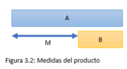

```python
#!pip install -q gdown

from IPython.display import display
from PIL import Image
import gdown

file_id = "1vY7leYaK73XjBlsLvg4Rm33xtgmRVFSm"
url = f"https://drive.google.com/uc?id={file_id}"

output = "./Graph2/Fig3-2.png"

#gdown.download(url, output, quiet=False)

img = Image.open('Graph2/Fig3-2.png')
display(img)
```